# R语言统计分析

小天使格礼

在Rstudio中安装本节课所有需要的包，运行以下指令：

```r
install.packages(c(
  "dplyr", "tidyr", "ggplot2",
  "psych", "pastecs", "e1071",
  "boot", "pwr", "reshape2",
  "car", "DescTools", "MASS",
  "vcd", "exact2x2", "coin",
  "multcomp", "emmeans", "afex",
  "ggpubr", "rstatix",
  "corrplot", "ppcor",
  "lm.beta", "broom"
))
```

# 目录

| 章节 | 主题 | 核心内容 |
| --- | --- | --- |
| 第一章 | 描述性统计基础 | 中心趋势、离散程度、分布形状度量 |
| 第二章 | 概率分布与随机变量 | 离散分布、连续分布、正态性检验 |
| 第三章 | 参数估计 | 点估计、置信区间、自举法 |
| 第四章 | 假设检验基础 | 原假设、p值、两类错误 |
| 第五章 | 常见参数检验 | t检验、比例检验、方差检验 |
| 第六章 | 非参数检验 | 秩检验、卡方检验、Fisher检验 |
| 第七章 | 方差分析 | 单因素、多因素、重复测量ANOVA |
| 第八章 | 相关分析与基础回归 | 相关系数、线性回归 |
| 第九章 | 样本量与功效分析 | 功效分析、样本量计算 |
| 第十章 | 统计模拟与重采样方法 | 蒙特卡洛模拟、自举法、置换检验 |

# 第一章：描述性统计基础

描述性统计是统计分析的第一步，它帮助我们了解数据的基本特征。在深入进行推断统计之前，我们需要先”认识”我们的数据——数据的中心在哪里？数据有多分散？数据的分布形状如何？这些问题都需要通过描述性统计来回答。

**为什么描述性统计如此重要？**

1. **数据质量检查**：通过描述性统计可以发现异常值、缺失值等问题
2. **选择合适的统计方法**：不同的数据分布需要不同的分析方法
3. **结果解读的基础**：了解数据的基本特征有助于正确解读分析结果
4. **数据报告的必要组成部分**：任何研究都需要报告样本的基本特征

## 1.1 中心趋势度量

中心趋势度量描述数据的”典型值”或”代表值”，告诉我们数据集中在哪个位置。不同的中心趋势度量适用于不同的数据类型和分布特征。

### 数学基础

设我们有一组数据 $x_1, x_2, ..., x_n$，各中心趋势度量的定义如下：

**均值（Mean）**：
$$\bar{x}
= \frac{1}{n}\sum_{i=1}^{n}x_i$$

**中位数（Median）**： 将数据从小到大排列后，位于中间位置的值。若n为奇数，中位数为第 $\frac{n+1}{2}$ 个值；若n为偶数，中位数为第 $\frac{n}{2}$ 和第 $\frac{n}{2}+1$ 个值的平均。

**众数（Mode）**： 出现次数最多的值。

**截尾均值（Trimmed Mean）**： 去掉最大和最小的p%数据后计算均值：
$$\bar{x}_{trimmed} =
\frac{1}{n(1-2p)}\sum_{i=[np]+1}^{n-[np]}x_{(i)}$$
其中 $x_{(i)}$ 表示排序后的第i个值。

### 使用场景与意义

| 度量指标 | 适用场景 | 优点 | 缺点 |
| --- | --- | --- | --- |
| 均值 | 对称分布、无极端值 | 利用所有信息、数学性质好 | 受极端值影响大 |
| 中位数 | 偏态分布、有极端值 | 不受极端值影响 | 信息利用不充分 |
| 众数 | 分类数据、多峰分布 | 适用于分类数据 | 可能不存在或不唯一 |
| 截尾均值 | 有少量极端值 | 兼顾稳健性和信息利用 | 需要选择截尾比例 |

```r
# 创建示例数据：某班级学生考试成绩
# 包含一些极端值（非常低或非常高的分数）
scores <- c(85, 78, 92, 88, 76, 95, 82, 79, 91, 87,
            84, 89, 77, 93, 86, 81, 90, 83, 88, 85,
            35, 98)  # 35和98是极端值

# 计算均值：所有数据的算术平均
# 均值 = 总和 / 个数
mean_score <- mean(scores)
mean_score
```

```
## [1] 83.72727
```

```r
# 计算中位数：将数据排序后取中间值
# 中位数不受极端值影响，更能代表"典型"水平
median_score <- median(scores)
median_score
```

```
## [1] 85.5
```

```r
# R基础包没有直接计算众数的函数
# 我们可以自定义一个函数来计算众数
get_mode <- function(x) {
  # 计算每个值出现的频数
  freq_table <- table(x)
  # 找出出现次数最多的值
  mode_value <- as.numeric(names(freq_table)[which.max(freq_table)])
  return(mode_value)
}

# 对于连续数据，众数可能不太有意义
# 让我们创建一个有明确众数的数据
grades <- c("A", "B", "B", "C", "B", "A", "B", "C", "B", "A")
# 计算众数（出现次数最多的等级）
mode_grade <- get_mode(grades)
mode_grade
```

```
## [1] NA
```

```r
# 截尾均值：去掉两端各10%的数据后计算均值
# 这可以减少极端值的影响
# trim参数指定截尾比例（两端各去掉的比例）
trimmed_mean <- mean(scores, trim = 0.1)
trimmed_mean
```

```
## [1] 85.44444
```

```r
# 比较不同的中心趋势度量
cat("原始均值:", mean_score, "\n")
```

```
## 原始均值: 83.72727
```

```r
cat("截尾均值:", trimmed_mean, "\n")
```

```
## 截尾均值: 85.44444
```

```r
cat("中位数:", median_score, "\n")
```

```
## 中位数: 85.5
```

```r
cat("均值与中位数的差异:", mean_score - median_score, "\n")
```

```
## 均值与中位数的差异: -1.772727
```

```r
# 差异较大说明数据可能存在偏态或极端值
```

**解读要点**： - 当均值 ≈ 中位数时，数据分布近似对称 - 当均值 > 中位数时，数据右偏（正偏），存在较大的极端值 - 当均值 < 中位数时，数据左偏（负偏），存在较小的极端值

## 1.2 离散程度度量

离散程度度量描述数据的”分散程度”或”变异性”，告诉我们数据围绕中心趋势的分布范围。仅知道中心趋势是不够的，我们还需要了解数据的波动情况。

### 数学基础

**方差（Variance）**：
$$s^2
= \frac{1}{n-1}\sum_{i=1}^{n}(x_i - \bar{x})^2$$

**标准差（Standard Deviation）**：
$$s = \sqrt{s^2} =
\sqrt{\frac{1}{n-1}\sum_{i=1}^{n}(x_i - \bar{x})^2}$$

**极差（Range）**：
$$R =
x_{max} - x_{min}$$

**四分位距（Interquartile Range, IQR）**：
$$IQR = Q_3 - Q_1$$
其中 $Q_1$ 是第25百分位数，$Q_3$ 是第75百分位数。

**变异系数（Coefficient of Variation, CV）**：
$$CV = \frac{s}{\bar{x}} \times 100\%$$

### 使用场景与意义

| 度量指标 | 适用场景 | 特点 |
| --- | --- | --- |
| 方差 | 统计推断的基础 | 单位是原单位的平方，不直观 |
| 标准差 | 描述数据分散程度 | 与原数据同单位，最常用 |
| 极差 | 快速了解数据范围 | 只利用两端信息，不稳定 |
| IQR | 有极端值时的稳健度量 | 不受极端值影响 |
| CV | 比较不同量纲数据的变异 | 无量纲，便于比较 |

```r
# 使用之前的考试成绩数据
scores <- c(85, 78, 92, 88, 76, 95, 82, 79, 91, 87,
            84, 89, 77, 93, 86, 81, 90, 83, 88, 85,
            35, 98)

# 计算方差：衡量数据偏离均值的程度
# 方差越大，数据越分散
var_scores <- var(scores)
var_scores
```

```
## [1] 152.684
```

```r
# 计算标准差：方差的平方根
# 标准差与原数据同单位，更易解释
sd_scores <- sd(scores)
sd_scores
```

```
## [1] 12.35654
```

```r
# 计算极差：最大值减最小值
# 极差只反映数据的范围，不反映中间分布
range_scores <- diff(range(scores))
range_scores
```

```
## [1] 63
```

```r
# 或者使用
range_result <- range(scores)
range_result
```

```
## [1] 35 98
```

```r
# 计算四分位距：第75百分位数 - 第25百分位数
# IQR是稳健的离散度量，不受极端值影响
iqr_scores <- IQR(scores)
iqr_scores
```

```
## [1] 8.5
```

```r
# 也可以用quantile函数计算
q1 <- quantile(scores, 0.25)
q3 <- quantile(scores, 0.75)
iqr_manual <- q3 - q1
iqr_manual
```

```
## 75%
## 8.5
```

```r
# 计算变异系数：标准差/均值
# CV是无量纲的，可用于比较不同量纲数据的变异程度
cv_scores <- sd(scores) / mean(scores) * 100
cv_scores
```

```
## [1] 14.75808
```

```r
# 示例：比较两组不同量纲数据的变异程度
# 身高数据（厘米）
height <- c(170, 175, 168, 172, 180, 165, 178, 173)
# 体重数据（千克）
weight <- c(65, 70, 62, 68, 75, 60, 72, 67)

# 直接比较标准差没有意义（单位不同）
sd(height)
```

```
## [1] 5.012484
```

```r
sd(weight)
```

```
## [1] 5.012484
```

```r
# 使用变异系数比较
cv_height <- sd(height) / mean(height) * 100
cv_weight <- sd(weight) / mean(weight) * 100
cat("身高CV:", cv_height, "%\n")
```

```
## 身高CV: 2.903684 %
```

```r
cat("体重CV:", cv_weight, "%\n")
```

```
## 体重CV: 7.43968 %
```

```r
# CV较大说明相对变异程度更大
```

**解读要点**： - 标准差与均值结合使用：对于正态分布，约68%的数据在均值±1个标准差范围内 - IQR与中位数结合使用：对于任何分布，约50%的数据在Q1到Q3范围内 - CV > 30%通常表示数据变异较大

## 1.3 分布形状度量

分布形状度量描述数据分布的对称性和尖锐程度，帮助我们判断数据是否符合正态分布等理论分布。

### 数学基础

**偏度（Skewness）**：
$$g_1
= \frac{n}{(n-1)(n-2)}\sum_{i=1}^{n}\left(\frac{x_i -
\bar{x}}{s}\right)^3$$

偏度衡量分布的对称性： - $g_1 = 0$：对称分布 - $g_1 > 0$：右偏（正偏），右侧有长尾 - $g_1 < 0$：左偏（负偏），左侧有长尾

**峰度（Kurtosis）**：
$$g_2
= \frac{n(n+1)}{(n-1)(n-2)(n-3)}\sum_{i=1}^{n}\left(\frac{x_i -
\bar{x}}{s}\right)^4 - \frac{3(n-1)^2}{(n-2)(n-3)}$$

峰度衡量分布的”尖峭”程度（相对于正态分布）： - $g_2 = 0$：与正态分布相同（正态峰） - $g_2 > 0$：尖峰分布（尾部更厚） - $g_2 < 0$：平峰分布（尾部更薄）

### 使用场景与意义

```r
# 创建不同分布特征的数据进行演示

# 对称分布数据
set.seed(123)
symmetric_data <- rnorm(1000, mean = 50, sd = 10)

# 右偏分布数据（如收入分布）
right_skewed <- rexp(1000, rate = 0.1)

# 左偏分布数据
left_skewed <- 100 - rexp(1000, rate = 0.1)

# 使用e1071包计算偏度和峰度
# type = 2 是默认类型，适用于小样本
# 偏度
skew_symmetric <- e1071::skewness(symmetric_data)
skew_right <- e1071::skewness(right_skewed)
skew_left <- e1071::skewness(left_skewed)

cat("对称分布偏度:", skew_symmetric, "\n")
```

```
## 对称分布偏度: 0.065196
```

```r
cat("右偏分布偏度:", skew_right, "\n")
```

```
## 右偏分布偏度: 1.68554
```

```r
cat("左偏分布偏度:", skew_left, "\n")
```

```
## 左偏分布偏度: -2.170876
```

```r
# 峰度
kurt_symmetric <- e1071::kurtosis(symmetric_data)
kurt_right <- e1071::kurtosis(right_skewed)
kurt_left <- e1071::kurtosis(left_skewed)

cat("对称分布峰度:", kurt_symmetric, "\n")
```

```
## 对称分布峰度: -0.08010201
```

```r
cat("右偏分布峰度:", kurt_right, "\n")
```

```
## 右偏分布峰度: 3.074591
```

```r
cat("左偏分布峰度:", kurt_left, "\n")
```

```
## 左偏分布峰度: 6.699674
```

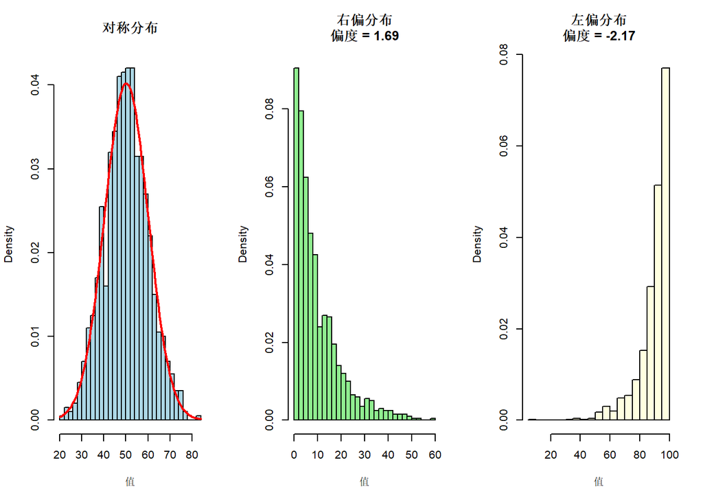

```r
# 可视化不同分布的形状
par(mfrow = c(1, 3))

# 对称分布
hist(symmetric_data, main = "对称分布",
     xlab = "值", col = "lightblue", breaks = 30, freq = FALSE)
curve(dnorm(x, mean = mean(symmetric_data), sd = sd(symmetric_data)),
      add = TRUE, col = "red", lwd = 2)

# 右偏分布
hist(right_skewed, main = paste("右偏分布\n偏度 =", round(skew_right, 2)),
     xlab = "值", col = "lightgreen", breaks = 30, freq = FALSE)

# 左偏分布
hist(left_skewed, main = paste("左偏分布\n偏度 =", round(skew_left, 2)),
     xlab = "值", col = "lightyellow", breaks = 30, freq = FALSE)
```

```r
par(mfrow = c(1, 1))
```

**解读要点**： - 偏度绝对值 > 1 表示严重偏态，可能需要数据转换 - 峰度绝对值 > 1 表示与正态分布差异较大 - 偏态会影响均值作为中心趋势度量的代表性

## 1.4 分位数与百分位数

分位数是将数据等分的分割点，百分位数是分位数的特例（将数据分为100等份）。它们在描述数据分布和确定参考范围时非常有用。

### 数学基础

第p百分位数 $P_p$ 是满足以下条件的值：
$$P(X \leq P_p) \geq
\frac{p}{100} \text{ 且 } P(X \geq P_p) \geq
\frac{100-p}{100}$$

常用的分位数包括： - 四分位数：将数据分为4等份（$Q_1=25\%, Q_2=50\%, Q_3=75\%$） - 十分位数：将数据分为10等份 - 百分位数：将数据分为100等份

### 使用场景与意义

分位数在医学参考值范围的确定中尤为重要。例如，儿童生长发育标准常用百分位数表示。

```r
# 使用考试成绩数据
scores <- c(85, 78, 92, 88, 76, 95, 82, 79, 91, 87,
            84, 89, 77, 93, 86, 81, 90, 83, 88, 85,
            35, 98)

# 计算四分位数
quartiles <- quantile(scores, probs = c(0.25, 0.5, 0.75))
quartiles
```

```
##   25%   50%   75%
## 81.25 85.50 89.75
```

```r
# 计算常用的百分位数
percentiles <- quantile(scores, probs = c(0.05, 0.10, 0.25, 0.50, 0.75, 0.90, 0.95))
percentiles
```

```
##    5%   10%   25%   50%   75%   90%   95%
## 76.05 77.10 81.25 85.50 89.75 92.90 94.90
```

```r
# 计算任意百分位数
# 例如，第10百分位数和第90百分位数
p10 <- quantile(scores, 0.10)
p90 <- quantile(scores, 0.90)
cat("第10百分位数:", p10, "\n")
```

```
## 第10百分位数: 77.1
```

```r
cat("第90百分位数:", p90, "\n")
```

```
## 第90百分位数: 92.9
```

```r
# 五数概括：最小值、Q1、中位数、Q3、最大值
fivenum(scores)
```

```
## [1] 35.0 81.0 85.5 90.0 98.0
```

```r
# 使用summary函数获取基本统计量
summary(scores)
```

```
##    Min. 1st Qu.  Median    Mean 3rd Qu.    Max.
##   35.00   81.25   85.50   83.73   89.75   98.00
```

```r
# 医学应用示例：儿童身高参考值
# 假设这是某年龄组男孩的身高数据（厘米）
set.seed(456)
boys_height <- rnorm(500, mean = 120, sd = 8)

# 计算常用百分位数（用于生长曲线）
height_percentiles <- quantile(boys_height, probs = c(0.03, 0.10, 0.25, 0.50, 0.75, 0.90, 0.97))
height_percentiles
```

```
##       3%      10%      25%      50%      75%      90%      97%
## 107.4552 110.9130 115.1824 120.6781 126.5114 130.9721 134.9521
```

```r
# 解释：第3百分位数意味着只有3%的儿童身高低于此值
# 常用于判断是否低于正常范围
```

**解读要点**： - 第50百分位数 = 中位数 - IQR = Q3 - Q1，反映中间50%数据的分布范围 - 医学上常用第5和第95百分位数（或第3和第97百分位数）作为参考范围

## 1.5 汇总统计函数

R提供了多种汇总统计函数，可以一次性获取多个统计量。常用的有`summary()`、`describe()`（psych包）和`stat.desc()`（pastecs包）。

### 使用场景与意义

不同的汇总函数提供不同详细程度和类型的统计量：

| 函数 | 来源 | 特点 |
| --- | --- | --- |
| summary() | 基础R | 提供基本六数概括 |
| describe() | psych包 | 提供偏度、峰度等更多统计量 |
| stat.desc() | pastecs包 | 提供最全面的描述统计 |

```r
# 创建示例数据框
# 模拟一项医学研究的基线数据
set.seed(789)
medical_data <- data.frame(
  patient_id = 1:50,
  age = round(rnorm(50, mean = 55, sd = 12)),
  bmi = round(rnorm(50, mean = 25, sd = 3), 1),
  sbp = round(rnorm(50, mean = 130, sd = 15)),  # 收缩压
  dbp = round(rnorm(50, mean = 85, sd = 10)),   # 舒张压
  glucose = round(rnorm(50, mean = 5.5, sd = 1), 1),  # 血糖
  group = sample(c("Treatment", "Control"), 50, replace = TRUE)
)

# 查看数据结构
str(medical_data)
```

```
## 'data.frame':    50 obs. of  7 variables:
##  $ patient_id: int  1 2 3 4 5 6 7 8 9 10 ...
##  $ age       : num  61 28 55 57 51 49 47 53 43 64 ...
##  $ bmi       : num  24.9 20.4 27.4 24.6 22.9 26.8 28.3 22.9 28.5 28.7 ...
##  $ sbp       : num  122 124 139 132 132 139 141 114 140 127 ...
##  $ dbp       : num  79 80 87 99 77 86 81 78 84 92 ...
##  $ glucose   : num  2.3 3.8 4.3 7.5 5.1 4.7 5.4 6.4 3.8 5.7 ...
##  $ group     : chr  "Control" "Control" "Treatment" "Treatment" ...
```

```r
# 使用summary()：基础R函数
# 提供最小值、Q1、中位数、均值、Q3、最大值
summary(medical_data)
```

```
##    patient_id         age             bmi             sbp
##  Min.   : 1.00   Min.   :18.00   Min.   :17.10   Min.   : 85.0
##  1st Qu.:13.25   1st Qu.:47.00   1st Qu.:22.95   1st Qu.:120.5
##  Median :25.50   Median :53.00   Median :25.45   Median :132.0
##  Mean   :25.50   Mean   :53.30   Mean   :25.20   Mean   :129.6
##  3rd Qu.:37.75   3rd Qu.:61.75   3rd Qu.:27.40   3rd Qu.:138.8
##  Max.   :50.00   Max.   :76.00   Max.   :32.00   Max.   :176.0
##       dbp            glucose         group
##  Min.   : 63.00   Min.   :2.300   Length:50
##  1st Qu.: 77.00   1st Qu.:4.825   Class :character
##  Median : 84.00   Median :5.350   Mode  :character
##  Mean   : 83.76   Mean   :5.378
##  3rd Qu.: 91.50   3rd Qu.:6.250
##  Max.   :105.00   Max.   :7.500
```

```r
# 使用psych包的describe()函数
# 提供更多统计量，包括标准差、偏度、峰度等
psych::describe(medical_data[, c("age", "bmi", "sbp", "dbp", "glucose")])
```

```
##         vars  n   mean    sd median trimmed   mad  min   max range  skew
## age        1 50  53.30 11.02  53.00   53.70 11.12 18.0  76.0  58.0 -0.52
## bmi        2 50  25.20  3.09  25.45   25.26  3.63 17.1  32.0  14.9 -0.17
## sbp        3 50 129.58 15.55 132.00  130.15 10.38 85.0 176.0  91.0 -0.19
## dbp        4 50  83.76 10.59  84.00   83.72 10.38 63.0 105.0  42.0  0.07
## glucose    5 50   5.38  1.02   5.35    5.42  0.96  2.3   7.5   5.2 -0.46
##         kurtosis   se
## age         0.84 1.56
## bmi        -0.43 0.44
## sbp         1.20 2.20
## dbp        -0.74 1.50
## glucose     0.16 0.14
```

```r
# 使用pastecs包的stat.desc()函数
# 提供最全面的描述统计，包括标准误、置信区间等
pastecs::stat.desc(medical_data[, c("age", "bmi", "sbp", "dbp", "glucose")])
```

```
##                       age          bmi          sbp          dbp     glucose
## nbr.val        50.0000000   50.0000000   50.0000000   50.0000000  50.0000000
## nbr.null        0.0000000    0.0000000    0.0000000    0.0000000   0.0000000
## nbr.na          0.0000000    0.0000000    0.0000000    0.0000000   0.0000000
## min            18.0000000   17.1000000   85.0000000   63.0000000   2.3000000
## max            76.0000000   32.0000000  176.0000000  105.0000000   7.5000000
## range          58.0000000   14.9000000   91.0000000   42.0000000   5.2000000
## sum          2665.0000000 1260.1000000 6479.0000000 4188.0000000 268.9000000
## median         53.0000000   25.4500000  132.0000000   84.0000000   5.3500000
## mean           53.3000000   25.2020000  129.5800000   83.7600000   5.3780000
## SE.mean         1.5587148    0.4366336    2.1992745    1.4979060   0.1443717
## CI.mean.0.95    3.1323547    0.8774481    4.4196075    3.0101548   0.2901258
## var           121.4795918    9.5324449  241.8404082  112.1861224   1.0421592
## std.dev        11.0217781    3.0874658   15.5512189   10.5917951   1.0208620
## coef.var        0.2067876    0.1225088    0.1200125    0.1264541   0.1898219
```

```r
# stat.desc()的norm = TRUE参数可进行正态性检验
pastecs::stat.desc(medical_data[, c("age", "bmi", "sbp")], norm = TRUE)
```

```
##                       age          bmi          sbp
## nbr.val        50.0000000   50.0000000   50.0000000
## nbr.null        0.0000000    0.0000000    0.0000000
## nbr.na          0.0000000    0.0000000    0.0000000
## min            18.0000000   17.1000000   85.0000000
## max            76.0000000   32.0000000  176.0000000
## range          58.0000000   14.9000000   91.0000000
## sum          2665.0000000 1260.1000000 6479.0000000
## median         53.0000000   25.4500000  132.0000000
## mean           53.3000000   25.2020000  129.5800000
## SE.mean         1.5587148    0.4366336    2.1992745
## CI.mean.0.95    3.1323547    0.8774481    4.4196075
## var           121.4795918    9.5324449  241.8404082
## std.dev        11.0217781    3.0874658   15.5512189
## coef.var        0.2067876    0.1225088    0.1200125
## skewness       -0.5182621   -0.1734366   -0.1870188
## skew.2SE       -0.7698469   -0.2576296   -0.2778051
## kurtosis        0.8369006   -0.4282681    1.1970114
## kurt.2SE        0.6321876   -0.3235101    0.9042123
## normtest.W      0.9679493    0.9891814    0.9610137
## normtest.p      0.1907601    0.9252156    0.0980297
```

```r
# skew.2SE和kurt.2SE列：如果绝对值>1，说明偏度/峰度显著
```

**解读要点**： - `describe()`中的`se`是标准误，反映均值估计的精度 - `stat.desc()`中的`skew.2SE`和`kurt.2SE`绝对值>1表示显著偏离正态

## 1.6 分组汇总

在实际研究中，我们经常需要按组计算统计量，例如比较不同治疗组的基线特征。R提供了多种分组汇总的方法。

### 使用场景与意义

分组汇总是数据探索和结果报告的基础，常用于： - 比较不同组别的基线特征 - 计算各组的描述性统计 - 生成汇总表格用于论文报告

```r
# 使用之前创建的医学数据
# 按组别计算各变量的描述性统计

# 方法1：使用tapply函数（基础R）
# tapply(数据, 分组变量, 统计函数)
# 计算各组的平均年龄
tapply(medical_data$age, medical_data$group, mean)
```

```
##   Control Treatment
##  51.08333  55.34615
```

```r
# 计算各组的年龄标准差
tapply(medical_data$age, medical_data$group, sd)
```

```
##   Control Treatment
##  10.02569  11.68569
```

```r
# 计算多个统计量
tapply(medical_data$age, medical_data$group, function(x) {
  c(mean = mean(x), sd = sd(x), min = min(x), max = max(x))
})
```

```
## $Control
##     mean       sd      min      max
## 51.08333 10.02569 28.00000 74.00000
##
## $Treatment
##     mean       sd      min      max
## 55.34615 11.68569 18.00000 76.00000
```

```r
# 方法2：使用aggregate函数（基础R）
# aggregate(公式, 数据, 统计函数)
# 计算各组的平均年龄
aggregate(age ~ group, data = medical_data, mean)
```

```
##       group      age
## 1   Control 51.08333
## 2 Treatment 55.34615
```

```r
# 计算多个变量的均值
aggregate(cbind(age, bmi, sbp) ~ group, data = medical_data, mean)
```

```
##       group      age      bmi      sbp
## 1   Control 51.08333 24.52500 124.5000
## 2 Treatment 55.34615 25.82692 134.2692
```

```r
# 方法3：使用dplyr包（推荐）
# dplyr提供更灵活和可读性更好的语法
# group_by() + summarise() 组合
medical_data %>%
  dplyr::group_by(group) %>%
  dplyr::summarise(
    n = dplyr::n(),                    # 样本量
    mean_age = mean(age),              # 平均年龄
    sd_age = sd(age),                  # 年龄标准差
    mean_bmi = mean(bmi),              # 平均BMI
    sd_bmi = sd(bmi),                  # BMI标准差
    mean_sbp = mean(sbp),              # 平均收缩压
    median_glucose = median(glucose)   # 血糖中位数
  )
```

```
## # A tibble: 2 × 8
##   group         n mean_age sd_age mean_bmi sd_bmi mean_sbp median_glucose
##   <chr>     <int>    <dbl>  <dbl>    <dbl>  <dbl>    <dbl>          <dbl>
## 1 Control      24     51.1   10.0     24.5   2.61     124.            5.3
## 2 Treatment    26     55.3   11.7     25.8   3.40     134.            5.6
```

```r
# 更复杂的分组汇总
# 计算各组的详细描述统计
group_summary <- medical_data %>%
  dplyr::group_by(group) %>%
  dplyr::summarise(
    across(c(age, bmi, sbp, dbp, glucose),
           list(mean = ~mean(.), sd = ~sd(.), median = ~median(.)),
           .names = "{.col}_{.fn}")
  )

# 查看结果
group_summary
```

```
## # A tibble: 2 × 16
##   group    age_mean age_sd age_median bmi_mean bmi_sd bmi_median sbp_mean sbp_sd
##   <chr>       <dbl>  <dbl>      <dbl>    <dbl>  <dbl>      <dbl>    <dbl>  <dbl>
## 1 Control      51.1   10.0       50.5     24.5   2.61       24.0     124.   14.7
## 2 Treatme…     55.3   11.7       58       25.8   3.40       26.6     134.   15.1
## # ℹ 7 more variables: sbp_median <dbl>, dbp_mean <dbl>, dbp_sd <dbl>,
## #   dbp_median <dbl>, glucose_mean <dbl>, glucose_sd <dbl>,
## #   glucose_median <dbl>
```

```r
# 使用psych包的describeBy函数
# 可以一次性获取各组的完整描述统计
psych::describeBy(medical_data[, c("age", "bmi", "sbp", "glucose")],
                  group = medical_data$group)
```

```
##
##  Descriptive statistics by group
## group: Control
##         vars  n   mean    sd median trimmed   mad  min   max range  skew
## age        1 24  51.08 10.03  50.50   51.00  6.67 28.0  74.0  46.0  0.11
## bmi        2 24  24.52  2.61  24.05   24.37  2.67 20.4  30.5  10.1  0.53
## sbp        3 24 124.50 14.70 127.50  125.95 14.08 85.0 143.0  58.0 -0.92
## glucose    4 24   5.25  1.01   5.30    5.34  0.82  2.3   6.6   4.3 -1.00
##         kurtosis   se
## age         0.04 2.05
## bmi        -0.46 0.53
## sbp         0.15 3.00
## glucose     0.84 0.21
## ------------------------------------------------------------
## group: Treatment
##         vars  n   mean    sd median trimmed   mad   min   max range  skew
## age        1 26  55.35 11.69   58.0   56.09  9.64  18.0  76.0  58.0 -1.03
## bmi        2 26  25.83  3.40   26.6   26.04  2.97  17.1  32.0  14.9 -0.69
## sbp        3 26 134.27 15.09  135.5  133.95 10.38 103.0 176.0  73.0  0.35
## glucose    4 26   5.50  1.03    5.6    5.50  1.26   3.8   7.5   3.7  0.01
##         kurtosis   se
## age         1.77 2.29
## bmi        -0.09 0.67
## sbp         0.84 2.96
## glucose    -1.11 0.20
```

**解读要点**： - `dplyr`方法语法清晰，适合复杂数据处理管道 - `describeBy()`适合快速生成报告用的描述统计表 - 分组汇总结果是论文”表1”的主要内容

## 1.7 频数表与列联表

频数表和列联表用于描述分类变量的分布情况，是分类数据分析的基础。

### 数学基础

**频数（Frequency）**：各类别的出现次数 **相对频数（Relative Frequency）**：各类别的比例
$$f_{rel} = \frac{n_i}{n}$$

**列联表（Contingency Table）**：两个或多个分类变量的交叉频数表

### 使用场景与意义

频数表和列联表在以下场景中常用： - 描述样本的基本特征（如性别、疾病分期分布） - 分析两个分类变量的关联性 - 为卡方检验等统计检验做准备

```r
# 创建分类变量数据
set.seed(111)
survey_data <- data.frame(
  gender = sample(c("Male", "Female"), 200, replace = TRUE),
  age_group = sample(c("Young", "Middle", "Senior"), 200, replace = TRUE),
  treatment = sample(c("Drug A", "Drug B", "Placebo"), 200, replace = TRUE),
  outcome = sample(c("Improved", "No Change", "Worsened"), 200, replace = TRUE)
)

# 单变量频数表
# 使用table()函数
gender_table <- table(survey_data$gender)
gender_table
```

```
##
## Female   Male
##    100    100
```

```r
# 添加边际合计
addmargins(gender_table)
```

```
##
## Female   Male    Sum
##    100    100    200
```

```r
# 计算比例（相对频数）
prop.table(gender_table)
```

```
##
## Female   Male
##    0.5    0.5
```

```r
# 转换为百分比
prop.table(gender_table) * 100
```

```
##
## Female   Male
##     50     50
```

```r
# 二维列联表（两个分类变量）
# 治疗方案与疗效的关系
treatment_outcome <- table(survey_data$treatment, survey_data$outcome)
treatment_outcome
```

```
##
##           Improved No Change Worsened
##   Drug A        20        19       18
##   Drug B        21        26       29
##   Placebo       20        26       21
```

```r
# 添加边际合计
addmargins(treatment_outcome)
```

```
##
##           Improved No Change Worsened Sum
##   Drug A        20        19       18  57
##   Drug B        21        26       29  76
##   Placebo       20        26       21  67
##   Sum           61        71       68 200
```

```r
# 计算行百分比（每组各类结果的比例）
# margin = 1 表示按行计算
prop.table(treatment_outcome, margin = 1) * 100
```

```
##
##           Improved No Change Worsened
##   Drug A  35.08772  33.33333 31.57895
##   Drug B  27.63158  34.21053 38.15789
##   Placebo 29.85075  38.80597 31.34328
```

```r
# 计算列百分比（各结果中不同组的比例）
# margin = 2 表示按列计算
prop.table(treatment_outcome, margin = 2) * 100
```

```
##
##           Improved No Change Worsened
##   Drug A  32.78689  26.76056 26.47059
##   Drug B  34.42623  36.61972 42.64706
##   Placebo 32.78689  36.61972 30.88235
```

```r
# 计算总百分比
prop.table(treatment_outcome) * 100
```

```
##
##           Improved No Change Worsened
##   Drug A      10.0       9.5      9.0
##   Drug B      10.5      13.0     14.5
##   Placebo     10.0      13.0     10.5
```

```r
# 使用xtabs()函数创建列联表（公式语法）
# 语法：xtabs(频数 ~ 行变量 + 列变量, data)
xtabs(~ treatment + outcome, data = survey_data)
```

```
##          outcome
## treatment Improved No Change Worsened
##   Drug A        20        19       18
##   Drug B        21        26       29
##   Placebo       20        26       21
```

```r
# 三维列联表
three_way <- xtabs(~ gender + treatment + outcome, data = survey_data)
three_way
```

```
## , , outcome = Improved
##
##         treatment
## gender   Drug A Drug B Placebo
##   Female      9      7       8
##   Male       11     14      12
##
## , , outcome = No Change
##
##         treatment
## gender   Drug A Drug B Placebo
##   Female      9     17      10
##   Male       10      9      16
##
## , , outcome = Worsened
##
##         treatment
## gender   Drug A Drug B Placebo
##   Female     11     19      10
##   Male        7     10      11
```

```r
# 查看特定维度的边际表
# 按性别分层查看治疗与疗效的关系
ftable(three_way)  # 扁平化显示
```

```
##                  outcome Improved No Change Worsened
## gender treatment
## Female Drug A                   9         9       11
##        Drug B                   7        17       19
##        Placebo                  8        10       10
## Male   Drug A                  11        10        7
##        Drug B                  14         9       10
##        Placebo                 12        16       11
```

```r
# 使用dplyr创建频数表
freq_table <- survey_data %>%
  dplyr::count(treatment, outcome) %>%
  dplyr::group_by(treatment) %>%
  dplyr::mutate(
    percent = n / sum(n) * 100,
    cum_percent = cumsum(percent)
  )
freq_table
```

```
## # A tibble: 9 × 5
## # Groups:   treatment [3]
##   treatment outcome       n percent cum_percent
##   <chr>     <chr>     <int>   <dbl>       <dbl>
## 1 Drug A    Improved     20    35.1        35.1
## 2 Drug A    No Change    19    33.3        68.4
## 3 Drug A    Worsened     18    31.6       100
## 4 Drug B    Improved     21    27.6        27.6
## 5 Drug B    No Change    26    34.2        61.8
## 6 Drug B    Worsened     29    38.2       100
## 7 Placebo   Improved     20    29.9        29.9
## 8 Placebo   No Change    26    38.8        68.7
## 9 Placebo   Worsened     21    31.3       100
```

```r
# 创建美观的汇总表
# 使用table()和prop.table()组合
create_crosstab <- function(data, row_var, col_var) {
  # 创建频数表
  freq <- table(data[[ row_var]], data[[col_var]])
  # 创建行百分比表
  row_pct <- prop.table(freq, 1) * 100
  # 合并为一个表格
  result <- matrix(paste0(freq, " (", round(row_pct, 1), "%)"),
                   nrow = nrow(freq))
  rownames(result) <- rownames(freq)
  colnames(result) <- colnames(freq)
  return(result)
}

create_crosstab(survey_data, "treatment", "outcome")
```

```
##         Improved     No Change    Worsened
## Drug A  "20 (35.1%)" "19 (33.3%)" "18 (31.6%)"
## Drug B  "21 (27.6%)" "26 (34.2%)" "29 (38.2%)"
## Placebo "20 (29.9%)" "26 (38.8%)" "21 (31.3%)"
```

**解读要点**： - 行百分比用于比较不同组的分布差异 - 列百分比用于了解某结果来自哪个组 - 列联表是卡方检验的基础

## 1.8 多变量描述：协方差与相关系数

当研究多个连续变量之间的关系时，协方差和相关系数是重要的描述性工具。

### 数学基础

**协方差（Covariance）**：
$$Cov(X,Y) = \frac{1}{n-1}\sum_{i=1}^{n}(x_i -
\bar{x})(y_i - \bar{y})$$

协方差的符号表示关系的方向： - $Cov > 0$：正相关（同向变化） - $Cov < 0$：负相关（反向变化） - $Cov = 0$：无线性相关

**Pearson相关系数**：
$$r =
\frac{Cov(X,Y)}{s_X \cdot s_Y} =
\frac{\sum(x_i-\bar{x})(y_i-\bar{y})}{\sqrt{\sum(x_i-\bar{x})^2 \cdot
\sum(y_i-\bar{y})^2}}$$

相关系数的范围：$-1 \leq r \leq 1$ - $|r| \approx 1$：强相关 - $|r| \approx 0$：弱相关或无相关

### 使用场景与意义

| 指标 | 范围 | 特点 |
| --- | --- | --- |
| 协方差 | $(-\infty, +\infty)$ | 受量纲影响，难以直接解释 |
| 相关系数 | $[-1, 1]$ | 无量纲，便于比较和解释 |

```r
# 使用医学数据演示协方差和相关系数

# 计算两个变量的协方差
# 收缩压和舒张压的协方差
cov_sb_db <- cov(medical_data$sbp, medical_data$dbp)
cov_sb_db
```

```
## [1] -11.38857
```

```r
# 计算相关系数
cor_sb_db <- cor(medical_data$sbp, medical_data$dbp)
cor_sb_db
```

```
## [1] -0.06914093
```

```r
# 相关系数的解释
if (abs(cor_sb_db) >= 0.8) {
  cat("强相关\n")
} else if (abs(cor_sb_db) >= 0.5) {
  cat("中等相关\n")
} else if (abs(cor_sb_db) >= 0.3) {
  cat("弱相关\n")
} else {
  cat("极弱或无相关\n")
}
```

```
## 极弱或无相关
```

```r
# 计算相关系数矩阵
# 多个变量之间的两两相关
cor_matrix <- cor(medical_data[, c("age", "bmi", "sbp", "dbp", "glucose")])
cor_matrix
```

```
##                  age          bmi         sbp          dbp     glucose
## age      1.000000000  0.003160536  0.01098979 -0.007587041  0.04993343
## bmi      0.003160536  1.000000000  0.10542960 -0.104017226  0.06573473
## sbp      0.010989793  0.105429600  1.00000000 -0.069140935 -0.11950275
## dbp     -0.007587041 -0.104017226 -0.06914093  1.000000000 -0.11091203
## glucose  0.049933435  0.065734733 -0.11950275 -0.110912034  1.00000000
```

```r
# 计算协方差矩阵
cov_matrix <- cov(medical_data[, c("age", "bmi", "sbp", "dbp", "glucose")])
cov_matrix
```

```
##                 age        bmi        sbp         dbp    glucose
## age     121.4795918  0.1075510   1.883673  -0.8857143  0.5618367
## bmi       0.1075510  9.5324449   5.062082  -3.4015510  0.2071878
## sbp       1.8836735  5.0620816 241.840408 -11.3885714 -1.8971837
## dbp      -0.8857143 -3.4015510 -11.388571 112.1861224 -1.1992653
## glucose   0.5618367  0.2071878  -1.897184  -1.1992653  1.0421592
```

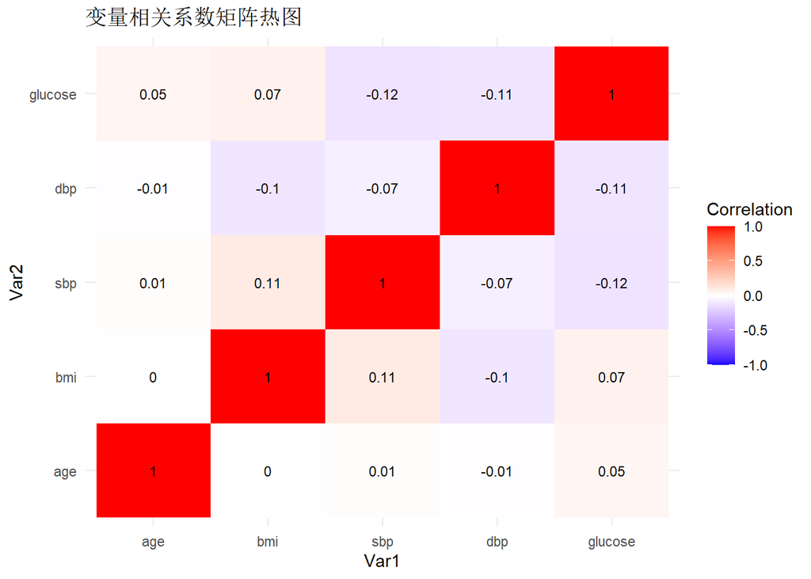

```r
# 可视化相关系数矩阵
# 使用corrplot包（如果已安装）
# 这里用基础方法演示
# 将相关矩阵转换为长格式
cor_df <- as.data.frame(as.table(cor_matrix))
names(cor_df) <- c("Var1", "Var2", "Correlation")

# 绘制热图
ggplot2::ggplot(cor_df, ggplot2::aes(x = Var1, y = Var2, fill = Correlation)) +
  ggplot2::geom_tile() +
  ggplot2::scale_fill_gradient2(low = "blue", mid = "white", high = "red",
                         midpoint = 0, limits = c(-1, 1)) +
  ggplot2::geom_text(ggplot2::aes(label = round(Correlation, 2)), size = 3) +
  ggplot2::theme_minimal() +
  ggplot2::labs(title = "变量相关系数矩阵热图")
```

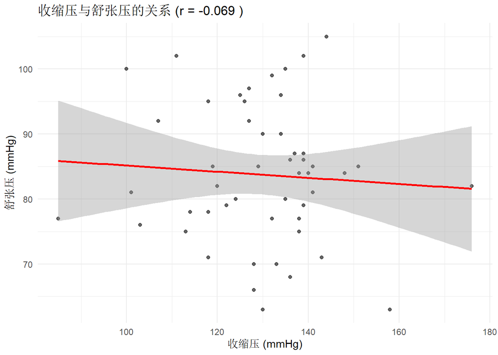

```r
# 散点图展示两个变量的关系
ggplot2::ggplot(medical_data, ggplot2::aes(x = sbp, y = dbp)) +
  ggplot2::geom_point(alpha = 0.6) +
  ggplot2::geom_smooth(method = "lm", se = TRUE, color = "red") +
  ggplot2::labs(title = paste("收缩压与舒张压的关系 (r =", round(cor_sb_db, 3), ")"),
       x = "收缩压 (mmHg)",
       y = "舒张压 (mmHg)") +
  ggplot2::theme_minimal()
```

```r
# 不同类型的相关系数
# Pearson相关（默认）：适用于连续变量、线性关系
cor_pearson <- cor(medical_data$sbp, medical_data$dbp, method = "pearson")

# Spearman相关：适用于等级数据或非线性单调关系
cor_spearman <- cor(medical_data$sbp, medical_data$dbp, method = "spearman")

# Kendall相关：适用于小样本或有序数据
cor_kendall <- cor(medical_data$sbp, medical_data$dbp, method = "kendall")

cat("Pearson相关:", cor_pearson, "\n")
```

```
## Pearson相关: -0.06914093
```

```r
cat("Spearman相关:", cor_spearman, "\n")
```

```
## Spearman相关: -0.009209166
```

```r
cat("Kendall相关:", cor_kendall, "\n")
```

```
## Kendall相关: -0.01499386
```

**解读要点**： - 相关系数只反映线性关系，不反映因果关系 - 相关系数受极端值影响，分析前应检查异常值 - Pearson相关假设数据近似正态分布，否则考虑Spearman相关

## 1.9 数据标准化与中心化

标准化和中心化是数据预处理的重要步骤，使不同量纲的变量具有可比性。

### 数学基础

**中心化（Centering）**：
$$x_{centered} = x - \bar{x}$$
中心化后的数据均值为0。

**标准化（Standardization/Z-score）**：
$$z = \frac{x - \bar{x}}{s}$$
标准化后的数据均值为0，标准差为1。

### 使用场景与意义

| 应用场景 | 说明 |
| --- | --- |
| 变量比较 | 消除量纲影响，使不同变量可比 |
| 回归分析 | 减少多重共线性，便于比较系数 |
| 聚类分析 | 防止大量纲变量主导距离计算 |
| 主成分分析 | 使各变量贡献相等 |

```r
# 使用医学数据演示标准化

# 原始数据的均值和标准差
cat("原始数据:\n")
```

```
## 原始数据:
```

```r
cat("年龄 - 均值:", mean(medical_data$age), "标准差:", sd(medical_data$age), "\n")
```

```
## 年龄 - 均值: 53.3 标准差: 11.02178
```

```r
cat("BMI - 均值:", mean(medical_data$bmi), "标准差:", sd(medical_data$bmi), "\n")
```

```
## BMI - 均值: 25.202 标准差: 3.087466
```

```r
cat("收缩压 - 均值:", mean(medical_data$sbp), "标准差:", sd(medical_data$sbp), "\n")
```

```
## 收缩压 - 均值: 129.58 标准差: 15.55122
```

```r
# 使用scale()函数进行标准化
# scale()默认进行中心化和标准化
age_scaled <- scale(medical_data$age)

# 标准化后的均值和标准差
cat("\n标准化后:\n")
```

```
##
## 标准化后:
```

```r
cat("年龄 - 均值:", mean(age_scaled), "标准差:", sd(age_scaled), "\n")
```

```
## 年龄 - 均值: 2.339101e-16 标准差: 1
```

```r
# 对多个变量进行标准化
scaled_vars <- scale(medical_data[, c("age", "bmi", "sbp", "dbp", "glucose")])
head(scaled_vars)
```

```
##             age         bmi        sbp        dbp    glucose
## [1,]  0.6986169 -0.09781485 -0.4874216 -0.4494045 -3.0150991
## [2,] -2.2954554 -1.55532089 -0.3588143 -0.3549918 -1.5457525
## [3,]  0.1542401  0.71191073  0.6057403  0.3058972 -1.0559704
## [4,]  0.3356990 -0.19498192  0.1556148  1.4388496  2.0786355
## [5,] -0.2086778 -0.74559531  0.1556148 -0.6382299 -0.2723189
## [6,] -0.3901367  0.51757659  0.6057403  0.2114845 -0.6641446
```

```r
# 检查标准化结果
cat("\n标准化后各变量的均值:\n")
```

```
##
## 标准化后各变量的均值:
```

```r
colMeans(scaled_vars)
```

```
##           age           bmi           sbp           dbp       glucose
##  2.339795e-16 -5.087597e-16 -7.920054e-16 -4.864165e-16 -1.386391e-16
```

```r
cat("\n标准化后各变量的标准差:\n")
```

```
##
## 标准化后各变量的标准差:
```

```r
apply(scaled_vars, 2, sd)
```

```
##     age     bmi     sbp     dbp glucose
##       1       1       1       1       1
```

```r
# 仅中心化（不减标准差）
# scale()的center和scale参数可单独控制
age_centered <- scale(medical_data$age, center = TRUE, scale = FALSE)
cat("\n仅中心化后的年龄均值:", mean(age_centered), "\n")
```

```
##
## 仅中心化后的年龄均值: 2.842344e-15
```

```r
cat("中心化后的年龄标准差:", sd(age_centered), "\n")
```

```
## 中心化后的年龄标准差: 11.02178
```

```r
# 仅标准化（不中心化）
# 通常不推荐，但某些情况下有用
age_scaled_only <- scale(medical_data$age, center = FALSE, scale = TRUE)
cat("\n仅标准化（不中心化）的均值:", mean(age_scaled_only), "\n")
```

```
##
## 仅标准化（不中心化）的均值: 0.9698371
```

```r
# 将标准化结果添加到数据框
medical_data_scaled <- medical_data
medical_data_scaled$age_z <- scale(medical_data$age)
medical_data_scaled$bmi_z <- scale(medical_data$bmi)
medical_data_scaled$sbp_z <- scale(medical_data$sbp)

head(medical_data_scaled)
```

```
##   patient_id age  bmi sbp dbp glucose     group      age_z       bmi_z
## 1          1  61 24.9 122  79     2.3   Control  0.6986169 -0.09781485
## 2          2  28 20.4 124  80     3.8   Control -2.2954554 -1.55532089
## 3          3  55 27.4 139  87     4.3 Treatment  0.1542401  0.71191073
## 4          4  57 24.6 132  99     7.5 Treatment  0.3356990 -0.19498192
## 5          5  51 22.9 132  77     5.1   Control -0.2086778 -0.74559531
## 6          6  49 26.8 139  86     4.7 Treatment -0.3901367  0.51757659
##        sbp_z
## 1 -0.4874216
## 2 -0.3588143
## 3  0.6057403
## 4  0.1556148
## 5  0.1556148
## 6  0.6057403
```

```r
# 标准化的实际应用示例
# 比较不同量纲变量的"异常程度"
# Z分数的绝对值越大，表示离均值越远

# 找出年龄最极端的5个样本
medical_data$age_z <- scale(medical_data$age)
medical_data %>%
  dplyr::arrange(dplyr::desc(abs(age_z))) %>%
  dplyr::select(patient_id, age, age_z) %>%
  head(5)
```

```
##   patient_id age     age_z
## 1         47  18 -3.202750
## 2          2  28 -2.295455
## 3         42  76  2.059559
## 4         43  74  1.878100
## 5         45  70  1.515182
```

```r
# 标准化在回归分析中的应用
# 当变量量纲差异很大时，标准化系数便于比较重要性
# 例如：年龄每增加1个标准差 vs BMI每增加1个标准差对血压的影响

# 创建标准化数据框用于回归
reg_data <- as.data.frame(scale(medical_data[, c("sbp", "age", "bmi")]))
head(reg_data)
```

```
##          sbp        age         bmi
## 1 -0.4874216  0.6986169 -0.09781485
## 2 -0.3588143 -2.2954554 -1.55532089
## 3  0.6057403  0.1542401  0.71191073
## 4  0.1556148  0.3356990 -0.19498192
## 5  0.1556148 -0.2086778 -0.74559531
## 6  0.6057403 -0.3901367  0.51757659
```

**解读要点**： - Z分数表示数据点距离均值有多少个标准差 - |Z| > 2 或 |Z| > 3 通常被视为异常值 - 标准化不改变变量之间的相关关系

## 第一章小结

| 类别 | 主要指标 | R函数 | 适用场景 |
| --- | --- | --- | --- |
| 中心趋势 | 均值、中位数、众数、截尾均值 | mean(), median() | 描述数据典型值 |
| 离散程度 | 方差、标准差、IQR、CV | var(), sd(), IQR() | 描述数据分散程度 |
| 分布形状 | 偏度、峰度 | e1071::skewness(), kurtosis() | 判断正态性 |
| 分位数 | 百分位数、四分位数 | quantile() | 确定参考范围 |
| 汇总统计 | 多指标汇总 | summary(), describe(), stat.desc() | 快速了解数据 |
| 分组汇总 | 按组计算统计量 | tapply(), aggregate(), dplyr | 比较组间差异 |
| 频数表 | 频数、比例 | table(), prop.table() | 分类变量描述 |
| 相关分析 | 协方差、相关系数 | cov(), cor() | 变量关系描述 |
| 数据变换 | 标准化、中心化 | scale() | 数据预处理 |

# 第二章：概率分布与随机变量

概率分布是统计推断的理论基础。理解各种概率分布的特征和应用场景，对于正确选择统计方法至关重要。本章将介绍常见的离散分布和连续分布，以及如何在R中进行相关计算。

**为什么学习概率分布？**

1. **统计推断的基础**：假设检验和置信区间的推导依赖于概率分布
2. **数据建模**：了解数据可能服从的分布有助于选择合适的分析方法
3. **模拟研究**：生成符合特定分布的随机数据用于模拟和验证
4. **风险评估**：计算特定事件发生的概率

## 2.1 离散分布

离散分布描述离散随机变量的概率分布，即随机变量只能取有限或可数无限个值。

### 数学基础

**概率质量函数（PMF）**：离散随机变量X取值为x的概率
$$P(X = x) = f(x)$$

**累积分布函数（CDF）**：随机变量小于等于某值的概率
$$F(x) = P(X \leq x) = \sum_{t \leq
x}f(t)$$

### 2.1.1 二项分布（Binomial Distribution）

**定义**：n次独立伯努利试验中成功次数X的分布

$$P(X = k) =
\binom{n}{k}p^k(1-p)^{n-k}$$

其中： - n：试验次数 - p：每次试验成功的概率 - k：成功次数（k = 0, 1, 2, …, n）

**期望与方差**：
$$E(X) = np,
\quad Var(X) = np(1-p)$$

**使用场景**： - n次治疗中治愈的患者数 - n次试验中成功的次数 - 样本中某种疾病的患者数

```r
# 二项分布示例：药物临床试验
# 假设某药物的有效率为60%（p = 0.6）
# 在20名患者中，有多少人会有效？

# 参数设置
n <- 20      # 试验次数（患者数）
p <- 0.6     # 成功概率（有效率）

# 计算恰好有k人有效的概率
# dbinom(x, size, prob) 计算概率质量函数
# 恰好有12人有效的概率
prob_12 <- dbinom(12, size = n, prob = p)
prob_12
```

```
## [1] 0.1797058
```

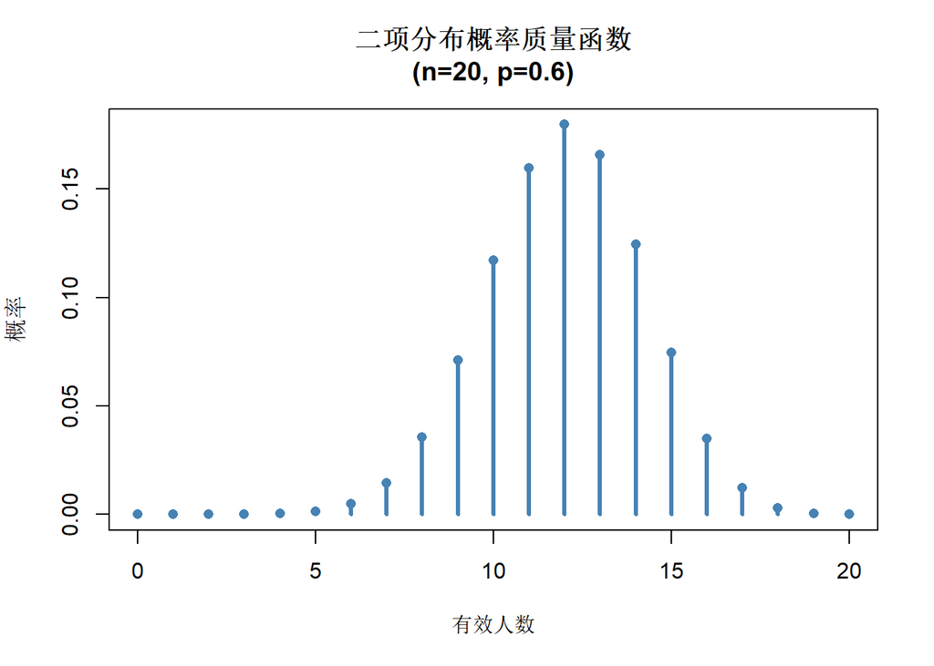

```r
# 计算不同成功次数的概率分布
k_values <- 0:n
probs <- dbinom(k_values, size = n, prob = p)

# 可视化二项分布
plot(k_values, probs, type = "h", lwd = 3, col = "steelblue",
     main = "二项分布概率质量函数\n(n=20, p=0.6)",
     xlab = "有效人数", ylab = "概率")
points(k_values, probs, pch = 16, col = "steelblue")
```

```r
# 计算累积概率
# pbinom(q, size, prob) 计算累积分布函数
# 最多有10人有效的概率
pbinom(10, size = n, prob = p)
```

```
## [1] 0.2446628
```

```r
# 至少有15人有效的概率
1 - pbinom(14, size = n, prob = p)
```

```
## [1] 0.125599
```

```r
# 计算分位数
# qbinom(p, size, prob) 计算分位数
# 95%的患者有效人数不超过多少？
qbinom(0.95, size = n, prob = p)
```

```
## [1] 16
```

```r
# 生成随机数
# rbinom(n, size, prob) 生成随机数
# 模拟100次试验，每次20名患者
set.seed(123)
sim_results <- rbinom(100, size = n, prob = p)
head(sim_results)
```

```
## [1] 13 10 13  9  9 16
```

```r
# 计算模拟结果的均值和理论期望
cat("模拟均值:", mean(sim_results), "\n")
```

```
## 模拟均值: 11.99
```

```r
cat("理论期望:", n * p, "\n")
```

```
## 理论期望: 12
```

### 2.1.2 泊松分布（Poisson Distribution）

**定义**：单位时间/空间内稀有事件发生次数的分布

$$P(X = k) = \frac{\lambda^k
e^{-\lambda}}{k!}$$

其中λ是单位时间/空间内事件的平均发生次数。

**期望与方差**：
$$E(X) =
Var(X) = \lambda$$

**使用场景**： - 单位时间内到达医院的急诊患者数 - 单位面积内某种疾病的发病数 - DNA序列中突变的次数

```r
# 泊松分布示例：急诊科患者到达
# 假设平均每小时有5名急诊患者到达

lambda <- 5  # 平均到达率

# 计算恰好有k名患者到达的概率
# dpois(x, lambda) 计算概率质量函数
# 恰好有3名患者到达的概率
dpois(3, lambda = lambda)
```

```
## [1] 0.1403739
```

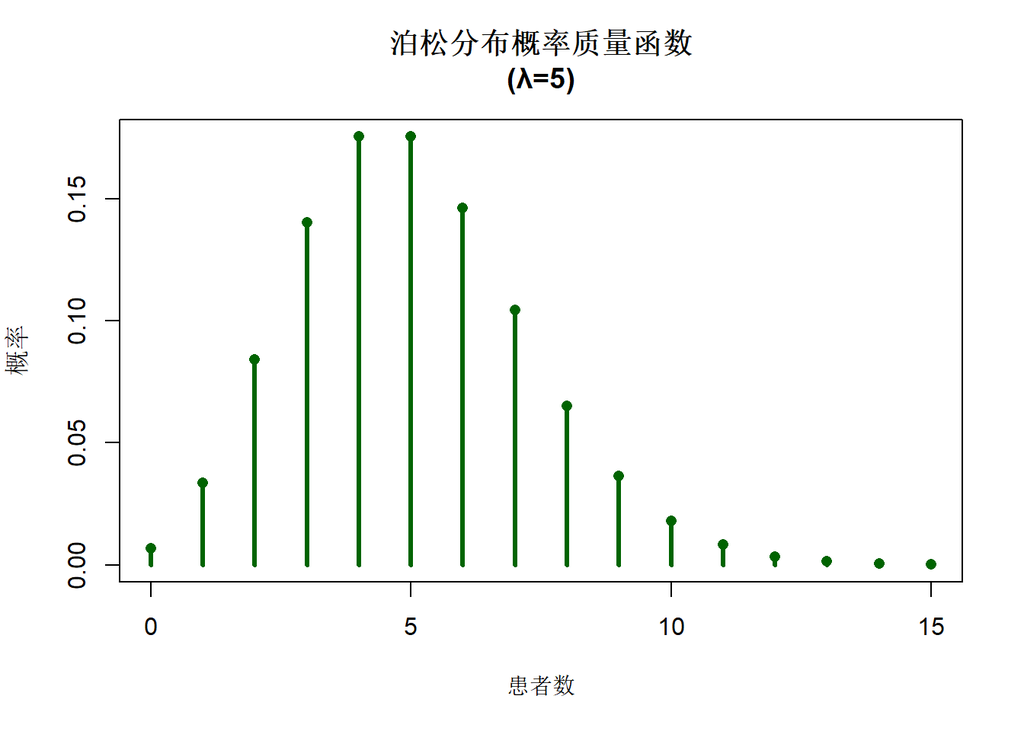

```r
# 计算不同患者数的概率分布
k_values <- 0:15
probs <- dpois(k_values, lambda = lambda)

# 可视化泊松分布
plot(k_values, probs, type = "h", lwd = 3, col = "darkgreen",
     main = "泊松分布概率质量函数\n(λ=5)",
     xlab = "患者数", ylab = "概率")
points(k_values, probs, pch = 16, col = "darkgreen")
```

```r
# 计算累积概率
# ppois(q, lambda) 计算累积分布函数
# 最多有3名患者到达的概率
ppois(3, lambda = lambda)
```

```
## [1] 0.2650259
```

```r
# 超过8名患者到达的概率
1 - ppois(8, lambda = lambda)
```

```
## [1] 0.06809363
```

```r
# 生成随机数
set.seed(456)
poisson_sim <- rpois(100, lambda = lambda)
head(poisson_sim)
```

```
## [1] 2 3 6 7 7 4
```

```r
# 比较模拟均值与理论期望
cat("模拟均值:", mean(poisson_sim), "\n")
```

```
## 模拟均值: 5.3
```

```r
cat("理论期望:", lambda, "\n")
```

```
## 理论期望: 5
```

### 2.1.3 几何分布与超几何分布

**几何分布**：首次成功所需的试验次数

$$P(X = k) = (1-p)^{k-1}p$$

**超几何分布**：不放回抽样中成功次数的分布

$$P(X = k) =
\frac{\binom{K}{k}\binom{N-K}{n-k}}{\binom{N}{n}}$$

```r
# 几何分布示例：首次成功所需的试验次数
# 假设治疗成功率为30%，首次成功需要多少次治疗？

p_success <- 0.3

# 计算第3次才成功的概率
# dgeom(x, prob) 中x是失败次数
# 第3次成功意味着前2次失败
dgeom(2, prob = p_success)
```

```
## [1] 0.147
```

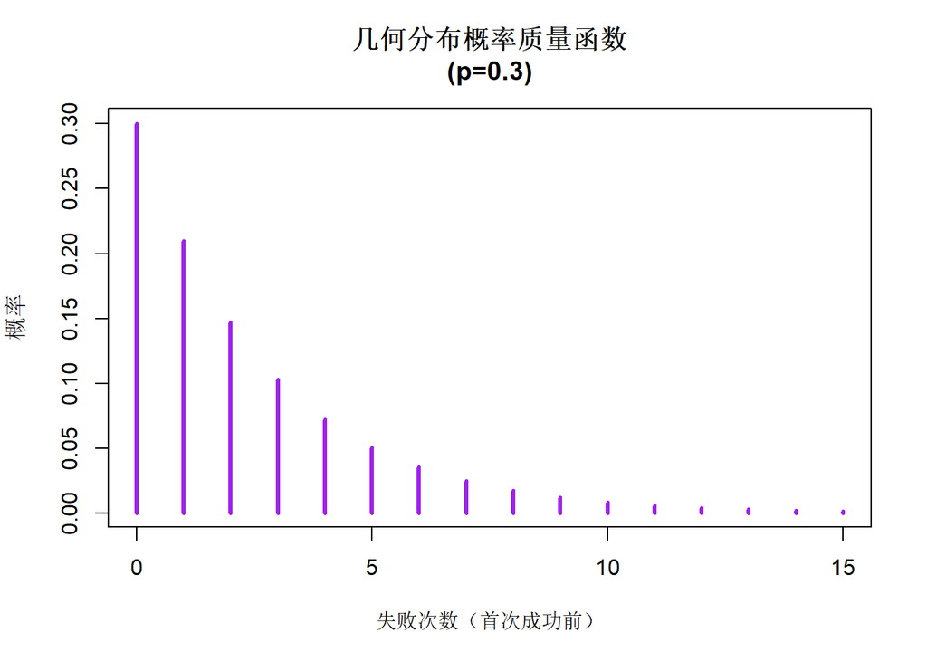

```r
# 可视化几何分布
k_values <- 0:15
probs <- dgeom(k_values, prob = p_success)

plot(k_values, probs, type = "h", lwd = 3, col = "purple",
     main = "几何分布概率质量函数\n(p=0.3)",
     xlab = "失败次数（首次成功前）", ylab = "概率")
```

```r
# 超几何分布示例：不放回抽样
# 假设一批药品中有10件次品，随机抽取5件，其中有多少次品？

# 参数
m <- 10   # 总体中成功的数量（次品数）
n <- 40   # 总体中失败的数量（合格品数）
k <- 5    # 抽取数量

# 计算恰好有2件次品的概率
# dhyper(x, m, n, k)
dhyper(2, m = m, n = n, k = k)
```

```
## [1] 0.2098397
```

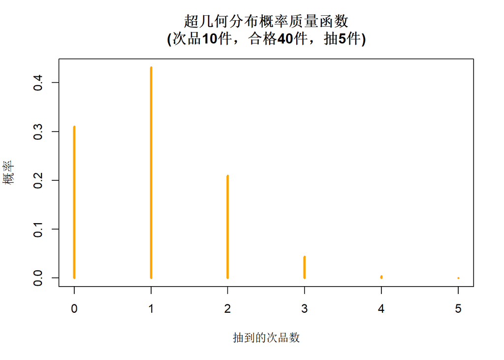

```r
# 计算概率分布
x_values <- 0:min(5, m)
probs <- dhyper(x_values, m = m, n = n, k = k)

# 可视化
plot(x_values, probs, type = "h", lwd = 3, col = "orange",
     main = "超几何分布概率质量函数\n(次品10件，合格40件，抽5件)",
     xlab = "抽到的次品数", ylab = "概率")
```

## 2.2 连续分布

连续分布描述连续随机变量的概率分布，随机变量可以取某一区间内的任意值。

### 数学基础

**概率密度函数（PDF）**：描述连续随机变量在各点的密度
$$P(a \leq X \leq b) = \int_a^b
f(x)dx$$

**性质**： - $f(x) \geq 0$ - $\int_{-\infty}^{+\infty}f(x)dx = 1$

### 2.2.1 正态分布（Normal Distribution）

正态分布（又称高斯分布）是统计学中最重要的分布，许多自然现象都近似服从正态分布。

**概率密度函数**：
$$f(x) =
\frac{1}{\sigma\sqrt{2\pi}}e^{-\frac{(x-\mu)^2}{2\sigma^2}}$$

**记号**：$X \sim N(\mu, \sigma^2)$

**标准正态分布**：$\mu = 0, \sigma = 1$，记为$Z \sim N(0,1)$

**使用场景**： - 身高、体重等生理指标 - 测量误差 - 大样本均值的抽样分布

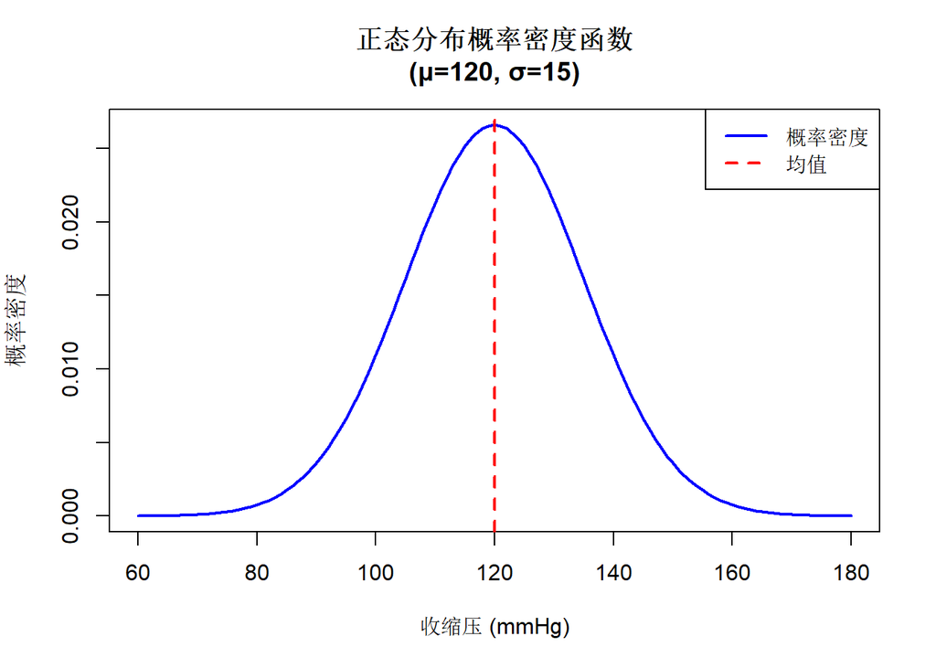

```r
# 正态分布示例：成人血压分布
# 假设收缩压服从均值为120，标准差为15的正态分布

mu <- 120   # 均值
sigma <- 15 # 标准差

# 计算概率密度
# dnorm(x, mean, sd) 计算概率密度函数
x_values <- seq(60, 180, by = 1)
density <- dnorm(x_values, mean = mu, sd = sigma)

# 可视化正态分布
plot(x_values, density, type = "l", lwd = 2, col = "blue",
     main = "正态分布概率密度函数\n(μ=120, σ=15)",
     xlab = "收缩压 (mmHg)", ylab = "概率密度")

# 添加均值线
abline(v = mu, col = "red", lty = 2, lwd = 2)
legend("topright", legend = c("概率密度", "均值"),
       col = c("blue", "red"), lty = c(1, 2), lwd = 2)
```

```r
# 计算累积概率
# pnorm(q, mean, sd) 计算累积分布函数
# 收缩压低于100的概率
pnorm(100, mean = mu, sd = sigma)
```

```
## [1] 0.09121122
```

```r
# 收缩压在100到140之间的概率
pnorm(140, mean = mu, sd = sigma) - pnorm(100, mean = mu, sd = sigma)
```

```
## [1] 0.8175776
```

```r
# 收缩压高于150的概率
1 - pnorm(150, mean = mu, sd = sigma)
```

```
## [1] 0.02275013
```

```r
# 计算分位数
# qnorm(p, mean, sd) 计算分位数
# 收缩压的第95百分位数
qnorm(0.95, mean = mu, sd = sigma)
```

```
## [1] 144.6728
```

```r
# 计算参考范围（95%参考范围）
lower <- qnorm(0.025, mean = mu, sd = sigma)
upper <- qnorm(0.975, mean = mu, sd = sigma)
cat("95%参考范围:", lower, "-", upper, "\n")
```

```
## 95%参考范围: 90.60054 - 149.3995
```

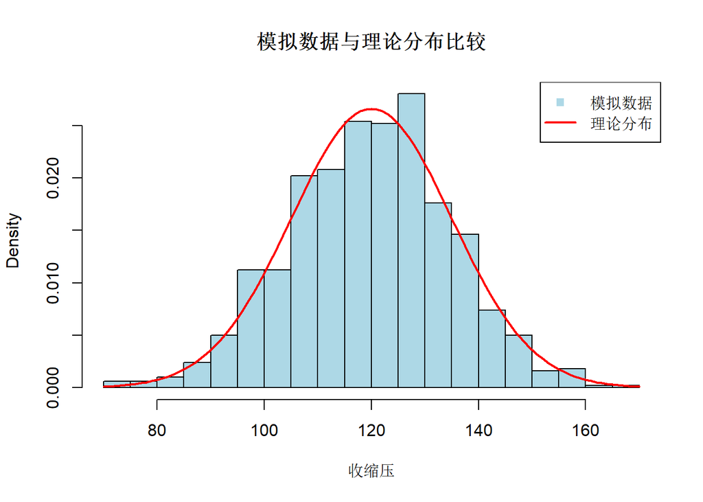

```r
# 生成随机数
set.seed(789)
bp_sim <- rnorm(1000, mean = mu, sd = sigma)

# 比较模拟结果与理论分布
hist(bp_sim, breaks = 30, probability = TRUE,
     main = "模拟数据与理论分布比较",
     xlab = "收缩压", col = "lightblue")
curve(dnorm(x, mean = mu, sd = sigma), add = TRUE, col = "red", lwd = 2)
legend("topright", legend = c("模拟数据", "理论分布"),
       col = c("lightblue", "red"), lty = c(NA, 1), lwd = c(NA, 2),
       pch = c(15, NA))
```

### 2.2.2 其他重要连续分布

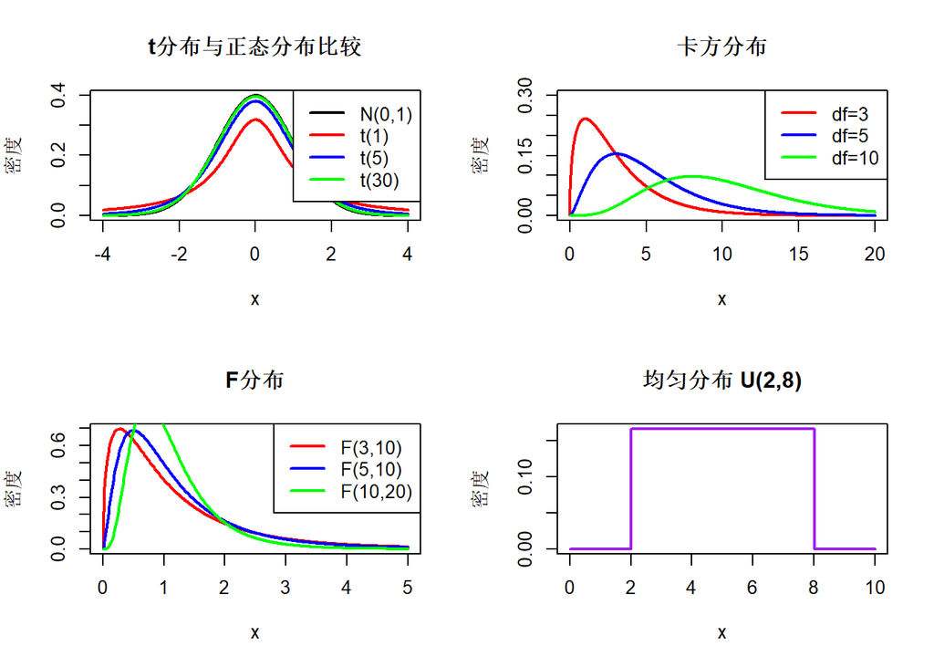

```r
# t分布：小样本推断
# t分布比正态分布有更厚的尾部，适用于小样本
# 自由度越大，t分布越接近正态分布

par(mfrow = c(2, 2))

# 比较不同自由度的t分布与标准正态分布
x <- seq(-4, 4, by = 0.01)
plot(x, dnorm(x), type = "l", lwd = 2, col = "black",
     main = "t分布与正态分布比较", ylab = "密度", xlab = "x")
lines(x, dt(x, df = 1), col = "red", lwd = 2)
lines(x, dt(x, df = 5), col = "blue", lwd = 2)
lines(x, dt(x, df = 30), col = "green", lwd = 2)
legend("topright", legend = c("N(0,1)", "t(1)", "t(5)", "t(30)"),
       col = c("black", "red", "blue", "green"), lwd = 2)

# 卡方分布：方差检验、拟合优度检验
# 自由度决定分布形状
x_chi <- seq(0, 20, by = 0.01)
plot(x_chi, dchisq(x_chi, df = 3), type = "l", lwd = 2, col = "red",
     main = "卡方分布", ylab = "密度", xlab = "x",
     xlim = c(0, 20), ylim = c(0, 0.3))
lines(x_chi, dchisq(x_chi, df = 5), col = "blue", lwd = 2)
lines(x_chi, dchisq(x_chi, df = 10), col = "green", lwd = 2)
legend("topright", legend = c("df=3", "df=5", "df=10"),
       col = c("red", "blue", "green"), lwd = 2)

# F分布：方差分析、方差比较
# 两个自由度参数
x_f <- seq(0, 5, by = 0.01)
plot(x_f, df(x_f, df1 = 3, df2 = 10), type = "l", lwd = 2, col = "red",
     main = "F分布", ylab = "密度", xlab = "x")
lines(x_f, df(x_f, df1 = 5, df2 = 10), col = "blue", lwd = 2)
lines(x_f, df(x_f, df1 = 10, df2 = 20), col = "green", lwd = 2)
legend("topright", legend = c("F(3,10)", "F(5,10)", "F(10,20)"),
       col = c("red", "blue", "green"), lwd = 2)

# 均匀分布：随机数生成的基础
x_unif <- seq(0, 10, by = 0.01)
plot(x_unif, dunif(x_unif, min = 2, max = 8), type = "l", lwd = 2, col = "purple",
     main = "均匀分布 U(2,8)", ylab = "密度", xlab = "x")
```

```r
par(mfrow = c(1, 1))
```

### 2.2.3 指数分布

**概率密度函数**：
$$f(x) =
\lambda e^{-\lambda x}, \quad x \geq 0$$

**使用场景**： - 事件发生的时间间隔 - 设备的寿命 - 患者等待时间

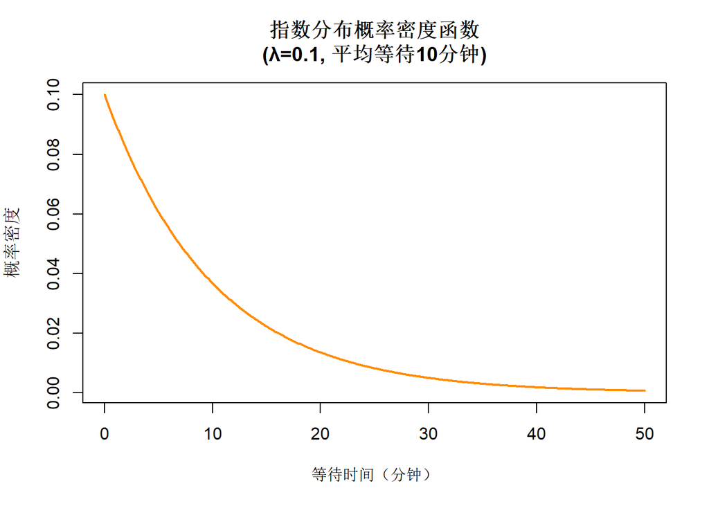

```r
# 指数分布示例：患者等待时间
# 假设平均等待时间为10分钟（λ = 0.1）

lambda_exp <- 0.1  # 速率参数（1/平均时间）

# 计算概率密度
x_exp <- seq(0, 50, by = 0.1)
density_exp <- dexp(x_exp, rate = lambda_exp)

# 可视化
plot(x_exp, density_exp, type = "l", lwd = 2, col = "darkorange",
     main = "指数分布概率密度函数\n(λ=0.1, 平均等待10分钟)",
     xlab = "等待时间（分钟）", ylab = "概率密度")
```

```r
# 计算等待时间少于5分钟的概率
pexp(5, rate = lambda_exp)
```

```
## [1] 0.3934693
```

```r
# 等待时间超过20分钟的概率
1 - pexp(20, rate = lambda_exp)
```

```
## [1] 0.1353353
```

```r
# 等待时间在5到15分钟之间的概率
pexp(15, rate = lambda_exp) - pexp(5, rate = lambda_exp)
```

```
## [1] 0.3834005
```

```r
# 中位数等待时间
qexp(0.5, rate = lambda_exp)
```

```
## [1] 6.931472
```

## 2.3 概率分布函数总结

R中概率分布函数的命名规则：

| 前缀 | 功能 | 示例 |
| --- | --- | --- |
| d | 概率密度/质量函数 (PDF/PMF) | dnorm(), dbinom() |
| p | 累积分布函数 (CDF) | pnorm(), pbinom() |
| q | 分位数函数 | qnorm(), qbinom() |
| r | 随机数生成 | rnorm(), rbinom() |

```r
# 综合示例：演示四种函数类型
# 以标准正态分布为例

# d - 密度函数：计算某点的密度值
dnorm(0, mean = 0, sd = 1)  # 均值处的密度最大
```

```
## [1] 0.3989423
```

```r
# p - 分布函数：计算累积概率
pnorm(1.96, mean = 0, sd = 1)  # Z=1.96以下的概率
```

```
## [1] 0.9750021
```

```r
# q - 分位数函数：计算给定概率对应的值
qnorm(0.975, mean = 0, sd = 1)  # 97.5%分位数
```

```
## [1] 1.959964
```

```r
# r - 随机数：生成随机样本
set.seed(111)
random_normal <- rnorm(5, mean = 0, sd = 1)
random_normal
```

```
## [1]  0.2352207 -0.3307359 -0.3116238 -2.3023457 -0.1708760
```

```r
# 常用分布函数汇总表
dist_summary <- data.frame(
  分布 = c("正态分布", "t分布", "卡方分布", "F分布",
           "二项分布", "泊松分布", "指数分布", "均匀分布"),
  R函数 = c("norm", "t", "chisq", "f", "binom", "pois", "exp", "unif"),
  主要参数 = c("mean, sd", "df", "df", "df1, df2",
               "size, prob", "lambda", "rate", "min, max"),
  应用场景 = c("连续变量、抽样分布", "小样本推断",
               "方差检验、拟合优度", "方差分析、方差比较",
               "成功次数", "计数数据", "等待时间", "随机数生成")
)
dist_summary
```

```
##       分布 R函数   主要参数           应用场景
## 1 正态分布  norm   mean, sd 连续变量、抽样分布
## 2    t分布     t         df         小样本推断
## 3 卡方分布 chisq         df 方差检验、拟合优度
## 4    F分布     f   df1, df2 方差分析、方差比较
## 5 二项分布 binom size, prob           成功次数
## 6 泊松分布  pois     lambda           计数数据
## 7 指数分布   exp       rate           等待时间
## 8 均匀分布  unif   min, max         随机数生成
```

## 2.4 正态性检验

许多统计方法假设数据服从正态分布，因此正态性检验是统计分析的重要步骤。

### 常用方法

1. **Shapiro-Wilk检验**：适用于小样本（n < 50）
2. **Kolmogorov-Smirnov检验**：适用于大样本
3. **Q-Q图**：直观判断

### 数学基础

**Shapiro-Wilk检验**： - 原假设H₀：数据来自正态分布 - 备择假设H₁：数据不来自正态分布 - p值 < 0.05 拒绝原假设，认为数据非正态

```r
# 创建正态和非正态数据
set.seed(222)
normal_data <- rnorm(100, mean = 50, sd = 10)
skewed_data <- rexp(100, rate = 0.1)  # 指数分布，右偏

# Shapiro-Wilk检验
# 正态数据的检验
shapiro.test(normal_data)
```

```
##
##  Shapiro-Wilk normality test
##
## data:  normal_data
## W = 0.97674, p-value = 0.07387
```

```r
# 偏态数据的检验
shapiro.test(skewed_data)
```

```
##
##  Shapiro-Wilk normality test
##
## data:  skewed_data
## W = 0.86574, p-value = 4.738e-08
```

```r
# Kolmogorov-Smirnov检验
# 将数据标准化后与标准正态分布比较
ks.test(scale(normal_data), "pnorm", mean = 0, sd = 1)
```

```
##
##  Asymptotic one-sample Kolmogorov-Smirnov test
##
## data:  scale(normal_data)
## D = 0.077204, p-value = 0.5902
## alternative hypothesis: two-sided
```

```r
ks.test(scale(skewed_data), "pnorm", mean = 0, sd = 1)
```

```
##
##  Asymptotic one-sample Kolmogorov-Smirnov test
##
## data:  scale(skewed_data)
## D = 0.12809, p-value = 0.07513
## alternative hypothesis: two-sided
```

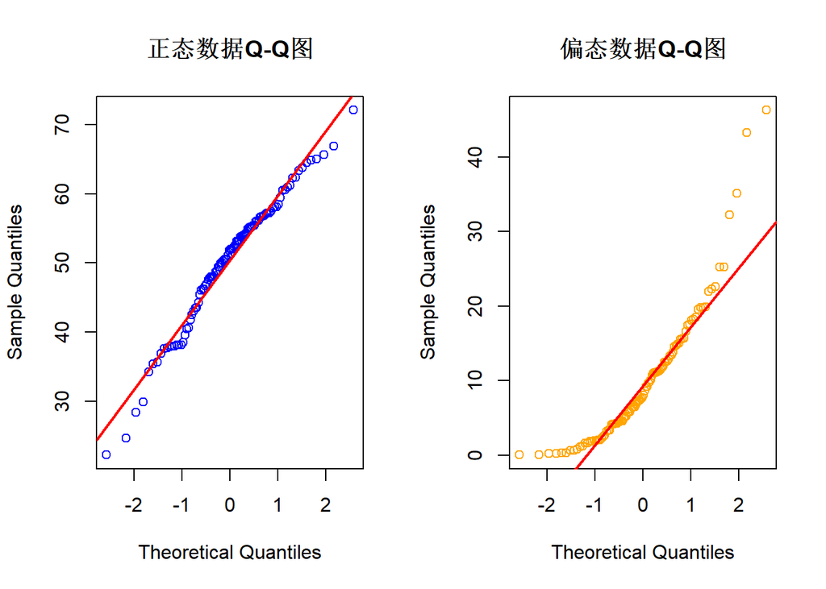

```r
# Q-Q图（分位数-分位数图）
# 正态数据的Q-Q图
par(mfrow = c(1, 2))

qqnorm(normal_data, main = "正态数据Q-Q图", col = "blue")
qqline(normal_data, col = "red", lwd = 2)

qqnorm(skewed_data, main = "偏态数据Q-Q图", col = "orange")
qqline(skewed_data, col = "red", lwd = 2)
```

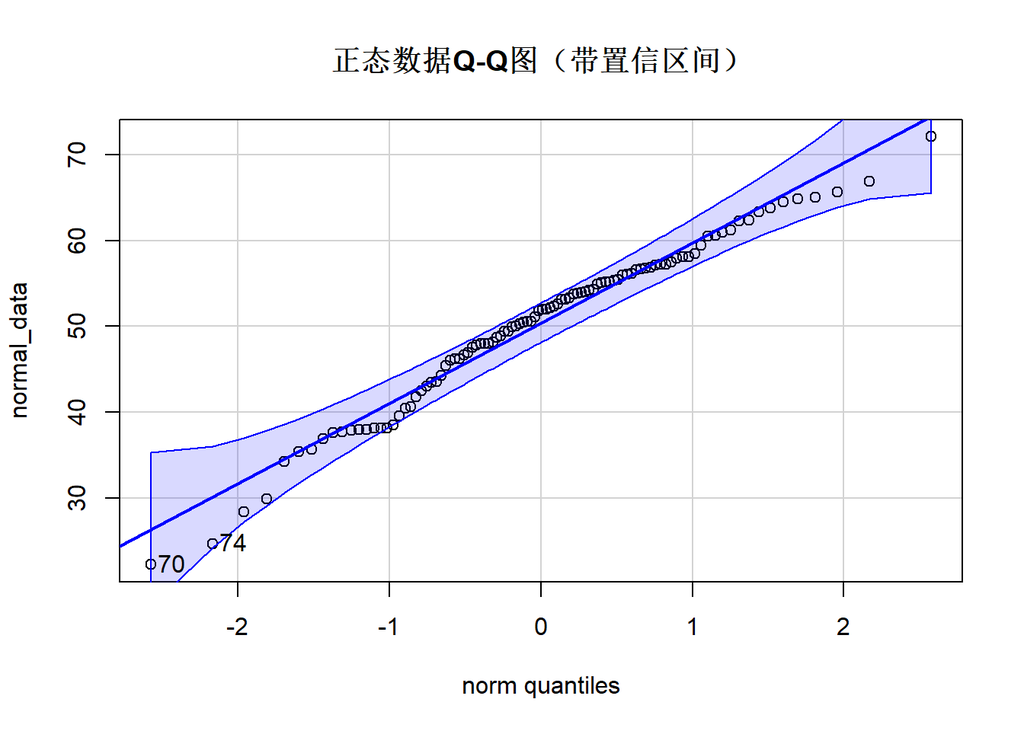

```
## [1] 70 74
```

```r
par(mfrow = c(1, 1))

# 使用car包绘制更详细的Q-Q图
# 包含置信区间
car::qqPlot(normal_data, main = "正态数据Q-Q图（带置信区间）")
```

**解读要点**： - Q-Q图中点近似落在直线上表示正态 - 两端偏离直线表示有偏态或重尾 - 检验的p值 > 0.05 不能拒绝正态假设 - 样本量很大时，检验可能过于敏感，应结合图形判断

## 2.5 中心极限定理与抽样分布

### 数学基础

**中心极限定理（CLT）**： 设 $X_1, X_2, ..., X_n$ 是独立同分布的随机变量，具有有限的均值μ和方差σ²，则当n足够大时：
$$\bar{X} \sim N\left(\mu,
\frac{\sigma^2}{n}\right)$$

**意义**：无论总体分布如何，样本均值的分布在大样本时近似正态分布。

**抽样分布**：统计量的概率分布，如样本均值的分布。

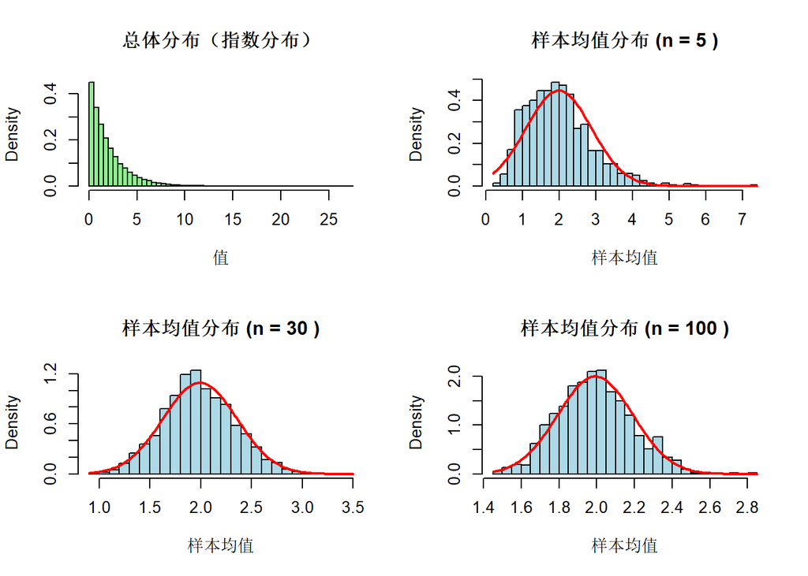

```r
# 演示中心极限定理
# 从非正态分布（指数分布）抽样，观察样本均值的分布

set.seed(333)

# 总体：指数分布（明显右偏）
population <- rexp(100000, rate = 0.5)

# 绘制总体分布
par(mfrow = c(2, 2))

hist(population, breaks = 50, main = "总体分布（指数分布）",
     xlab = "值", col = "lightgreen", probability = TRUE)

# 不同样本量下样本均值的分布
sample_sizes <- c(5, 30, 100)
n_simulations <- 1000  # 模拟次数

for (i in seq_along(sample_sizes)) {
  n <- sample_sizes[i]

  # 进行多次抽样，计算样本均值
  sample_means <- replicate(n_simulations, {
    sample_data <- sample(population, size = n)
    mean(sample_data)
  })

  # 绘制样本均值的分布
  hist(sample_means, breaks = 30,
       main = paste("样本均值分布 (n =", n, ")"),
       xlab = "样本均值", col = "lightblue", probability = TRUE)

  # 叠加正态分布曲线
  curve(dnorm(x, mean = mean(population),
              sd = sd(population)/sqrt(n)),
        add = TRUE, col = "red", lwd = 2)
}
```

```r
par(mfrow = c(1, 1))

# 理论值与模拟值比较
cat("总体均值:", mean(population), "\n")
```

```
## 总体均值: 1.992382
```

```r
cat("总体标准差:", sd(population), "\n")
```

```
## 总体标准差: 1.998025
```

```r
cat("样本均值的理论标准误:", sd(population)/sqrt(30), "\n")
```

```
## 样本均值的理论标准误: 0.3647878
```

```r
cat("模拟的样本均值标准差:", sd(replicate(1000, mean(sample(population, 30)))), "\n")
```

```
## 模拟的样本均值标准差: 0.3681116
```

## 2.6 大数定律

### 数学基础

**大数定律**：当样本量n趋向无穷时，样本均值依概率收敛于总体均值。

$$\bar{X}_n \xrightarrow{P} \mu \quad
\text{当} \quad n \to \infty$$

**意义**：样本量越大，样本统计量越接近总体参数。

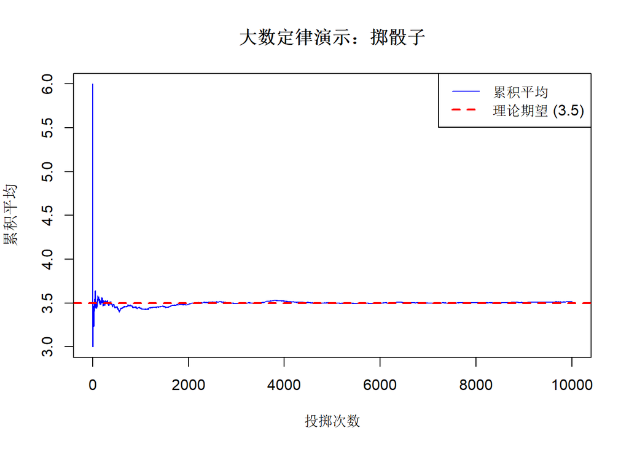

```r
# 演示大数定律
set.seed(444)

# 模拟掷骰子（期望值为3.5）
n_rolls <- 10000
rolls <- sample(1:6, n_rolls, replace = TRUE)

# 计算累积均值
cumulative_mean <- cumsum(rolls) / (1:n_rolls)

# 绘制累积均值随样本量的变化
plot(1:n_rolls, cumulative_mean, type = "l",
     main = "大数定律演示：掷骰子",
     xlab = "投掷次数", ylab = "累积平均",
     col = "blue", lwd = 1)
abline(h = 3.5, col = "red", lwd = 2, lty = 2)
legend("topright", legend = c("累积平均", "理论期望 (3.5)"),
       col = c("blue", "red"), lty = c(1, 2), lwd = c(1, 2))
```

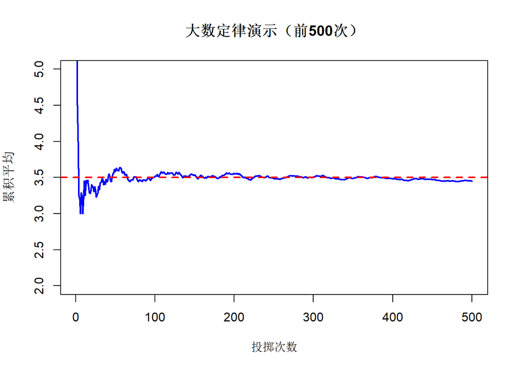

```r
# 放大前500次
plot(1:500, cumulative_mean[1:500], type = "l",
     main = "大数定律演示（前500次）",
     xlab = "投掷次数", ylab = "累积平均",
     col = "blue", lwd = 2, ylim = c(2, 5))
abline(h = 3.5, col = "red", lwd = 2, lty = 2)
```

## 第二章小结

| 内容 | 关键概念 | R函数 |
| --- | --- | --- |
| 离散分布 | 二项分布、泊松分布 | dbinom(), dpois() |
| 连续分布 | 正态分布、t分布、卡方分布、F分布 | dnorm(), dt(), dchisq(), df() |
| 分布函数 | d/p/q/r 四类函数 | dnorm(), pnorm(), qnorm(), rnorm() |
| 正态性检验 | Shapiro-Wilk, Q-Q图 | shapiro.test(), qqnorm() |
| 中心极限定理 | 样本均值的正态性 | 模拟演示 |
| 大数定律 | 样本均值收敛于总体均值 | 模拟演示 |

# 第三章：参数估计

参数估计是统计推断的核心内容之一，它利用样本数据来推断总体参数。参数估计分为点估计和区间估计两种形式，本章将详细介绍这两种方法及其在R中的实现。

**为什么需要参数估计？**

1. **总体参数未知**：我们通常无法获得整个总体的数据，只能通过样本推断
2. **科学决策**：基于数据做出合理的决策需要了解参数的可能范围
3. **研究结论的可靠性**：区间估计提供了估计的不确定性信息

## 3.1 点估计

点估计是用样本统计量直接估计总体参数的方法。

### 3.1.1 矩估计法

**数学基础**：

矩估计的基本思想是用样本矩估计总体矩。设总体有k个未知参数，用前k阶样本矩等于相应的总体矩，解方程组得到参数估计。

**一阶矩（均值）**：
$$\bar{X} = \frac{1}{n}\sum_{i=1}^{n}X_i
\rightarrow E(X) = \mu$$

**二阶矩（方差）**：
$$S^2 =
\frac{1}{n}\sum_{i=1}^{n}(X_i - \bar{X})^2 \rightarrow Var(X) =
\sigma^2$$

```r
# 矩估计示例：正态分布参数估计
set.seed(555)

# 从已知参数的正态分布生成样本
true_mu <- 100
true_sigma <- 15
n <- 50
sample_data <- rnorm(n, mean = true_mu, sd = true_sigma)

# 矩估计：用样本均值估计总体均值
mu_moment <- mean(sample_data)
mu_moment
```

```
## [1] 100.3589
```

```r
# 矩估计：用样本方差估计总体方差
# 注意：样本方差有两种计算方式
# 有偏估计（总体方差）：除以n
sigma2_biased <- mean((sample_data - mu_moment)^2)
# 无偏估计：除以n-1
sigma2_unbiased <- var(sample_data)

cat("真实均值:", true_mu, "\n")
```

```
## 真实均值: 100
```

```r
cat("矩估计均值:", mu_moment, "\n")
```

```
## 矩估计均值: 100.3589
```

```r
cat("真实方差:", true_sigma^2, "\n")
```

```
## 真实方差: 225
```

```r
cat("矩估计方差（有偏）:", sigma2_biased, "\n")
```

```
## 矩估计方差（有偏）: 222.5963
```

```r
cat("矩估计方差（无偏）:", sigma2_unbiased, "\n")
```

```
## 矩估计方差（无偏）: 227.1391
```

### 3.1.2 极大似然估计（MLE）

**数学基础**：

极大似然估计寻找使观测数据出现概率最大的参数值。

**似然函数**：
$$L(\theta) =
\prod_{i=1}^{n}f(x_i|\theta)$$

**对数似然函数**：
$$\ell(\theta) = \sum_{i=1}^{n}\ln
f(x_i|\theta)$$

**MLE估计量**：
$$\hat{\theta}_{MLE} = \arg\max_{\theta}
L(\theta)$$

对于正态分布 $X \sim N(\mu, \sigma^2)$： - $\hat{\mu}_{MLE} = \bar{X}$ - $\hat{\sigma}^2_{MLE} = \frac{1}{n}\sum_{i=1}^{n}(X_i - \bar{X})^2$

```r
# 极大似然估计示例

# 方法1：手动计算正态分布的MLE
# 对于正态分布，均值的MLE就是样本均值
mu_mle <- mean(sample_data)
# 标准差的MLE（有偏版本）
sigma_mle <- sqrt(mean((sample_data - mu_mle)^2))

cat("MLE均值估计:", mu_mle, "\n")
```

```
## MLE均值估计: 100.3589
```

```r
cat("MLE标准差估计:", sigma_mle, "\n")
```

```
## MLE标准差估计: 14.91966
```

```r
# 方法2：使用MASS包的fitdistr函数进行MLE
# 自动计算多种分布的MLE
mle_result <- MASS::fitdistr(sample_data, "normal")
mle_result
```

```
##       mean          sd
##   100.358878    14.919662
##  (  2.109959) (  1.491966)
```

```r
# 方法3：自定义似然函数进行优化
# 定义正态分布的对数似然函数
log_likelihood <- function(params, data) {
  mu <- params[1]
  sigma <- params[2]
  # 约束sigma > 0
  if (sigma <= 0) return(-Inf)
  # 计算对数似然
  ll <- sum(dnorm(data, mean = mu, sd = sigma, log = TRUE))
  return(ll)
}

# 使用optim函数最大化对数似然
# 初始值
init_params <- c(mean(sample_data), sd(sample_data))
# 优化（最大化似然等价于最小化负似然）
mle_optim <- optim(init_params, function(p) -log_likelihood(p, sample_data),
                   method = "L-BFGS-B", lower = c(-Inf, 0.001))

cat("\n自定义优化结果:\n")
```

```
##
## 自定义优化结果:
```

```r
cat("均值:", mle_optim$par[1], "\n")
```

```
## 均值: 100.3589
```

```r
cat("标准差:", mle_optim$par[2], "\n")
```

```
## 标准差: 14.91966
```

```r
# 比较不同方法的结果
comparison <- data.frame(
  方法 = c("真实值", "矩估计", "MLE(fitdistr)", "MLE(optim)"),
  均值 = c(true_mu, mu_moment, mle_result$estimate[1], mle_optim$par[1]),
  标准差 = c(true_sigma, sqrt(sigma2_unbiased), mle_result$estimate[2], mle_optim$par[2])
)
comparison
```

```
##            方法     均值   标准差
## 1        真实值 100.0000 15.00000
## 2        矩估计 100.3589 15.07113
## 3 MLE(fitdistr) 100.3589 14.91966
## 4    MLE(optim) 100.3589 14.91966
```

## 3.2 估计量的评价标准

不同的估计方法可能得到不同的估计量，我们需要评价估计量的优劣。

### 数学基础

**无偏性（Unbiasedness）**：
$$E(\hat{\theta}) = \theta$$
估计量的期望等于真实参数值。

**有效性（Efficiency）**： 在所有无偏估计量中，方差最小的估计量最有效。

**一致性（Consistency）**：
$$\hat{\theta}_n \xrightarrow{P} \theta \quad
\text{当} \quad n \to \infty$$
样本量增大时，估计量收敛于真实参数。

```r
# 演示无偏性和一致性
set.seed(666)

# 比较样本方差的有偏和无偏估计
n_simulations <- 10000
true_var <- 225  # 真实方差 (15^2)

# 存储不同样本量下的估计结果
sample_sizes <- c(10, 30, 100, 500)

results <- data.frame()

for (n in sample_sizes) {
  biased_estimates <- numeric(n_simulations)
  unbiased_estimates <- numeric(n_simulations)

  for (i in 1:n_simulations) {
    sample_data <- rnorm(n, mean = 100, sd = 15)
    # 有偏估计（除以n）
    biased_estimates[i] <- mean((sample_data - mean(sample_data))^2)
    # 无偏估计（除以n-1）
    unbiased_estimates[i] <- var(sample_data)
  }

  results <- rbind(results, data.frame(
    n = n,
    方法 = "有偏估计",
    均值 = mean(biased_estimates),
    偏差 = mean(biased_estimates) - true_var,
    方差 = var(biased_estimates)
  ))

  results <- rbind(results, data.frame(
    n = n,
    方法 = "无偏估计",
    均值 = mean(unbiased_estimates),
    偏差 = mean(unbiased_estimates) - true_var,
    方差 = var(unbiased_estimates)
  ))
}

# 查看结果
results
```

```
##     n     方法     均值         偏差       方差
## 1  10 有偏估计 202.0247 -22.97534650  8993.0528
## 2  10 无偏估计 224.4718  -0.52816278 11102.5343
## 3  30 有偏估计 217.2684  -7.73163421  3267.1957
## 4  30 无偏估计 224.7604  -0.23962160  3496.4044
## 5 100 有偏估计 222.6066  -2.39335395  1004.0881
## 6 100 无偏估计 224.8552  -0.14480197  1024.4752
## 7 500 有偏估计 224.4865  -0.51350947   203.2422
## 8 500 无偏估计 224.9364  -0.06363675   204.0576
```

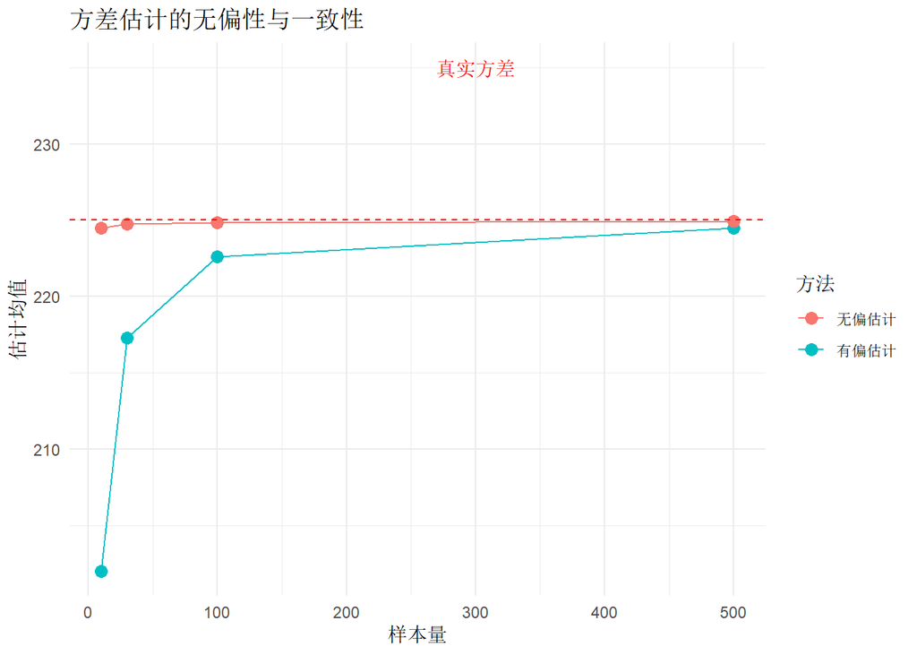

```r
# 可视化：随着样本量增加，两种估计都趋于真值
library(ggplot2)
ggplot2::ggplot(results, ggplot2::aes(x = n, y = 均值, color = 方法)) +
  ggplot2::geom_point(size = 3) +
  ggplot2::geom_line() +
  ggplot2::geom_hline(yintercept = true_var, linetype = "dashed", color = "red") +
  ggplot2::labs(title = "方差估计的无偏性与一致性",
       x = "样本量", y = "估计均值") +
  ggplot2::theme_minimal() +
  ggplot2::annotate("text", x = 300, y = true_var + 10, label = "真实方差", color = "red")
```

## 3.3 置信区间基本原理

### 数学基础

**置信区间定义**： 对于参数θ，如果统计量 $\hat{\theta}_L$ 和 $\hat{\theta}_U$ 满足：
$$P(\hat{\theta}_L \leq \theta \leq \hat{\theta}_U)
= 1 - \alpha$$
则称 $[\hat{\theta}_L, \hat{\theta}_U]$ 为θ的 $(1-\alpha)$ 置信区间。

**正确理解置信区间**： - 不是”参数有95%的概率落在区间内” - 而是”如果重复抽样多次，95%的区间会包含真实参数”

```r
# 演示置信区间的含义
set.seed(777)

# 参数设置
true_mu <- 50
true_sigma <- 10
n <- 30
n_intervals <- 100  # 生成100个置信区间

# 存储结果
intervals <- matrix(NA, nrow = n_intervals, ncol = 3)
colnames(intervals) <- c("lower", "mean", "upper")

# 生成多个置信区间
for (i in 1:n_intervals) {
  sample_data <- rnorm(n, mean = true_mu, sd = true_sigma)
  sample_mean <- mean(sample_data)
  sample_se <- sd(sample_data) / sqrt(n)
  # 95%置信区间
  intervals[i, ] <- c(
    sample_mean - qt(0.975, df = n-1) * sample_se,
    sample_mean,
    sample_mean + qt(0.975, df = n-1) * sample_se
  )
}

# 计算有多少区间包含真实均值
contains_true <- (intervals[, "lower"] <= true_mu) & (intervals[, "upper"] >= true_mu)
coverage_rate <- mean(contains_true)
cat("覆盖率:", coverage_rate * 100, "%\n")
```

```
## 覆盖率: 94 %
```

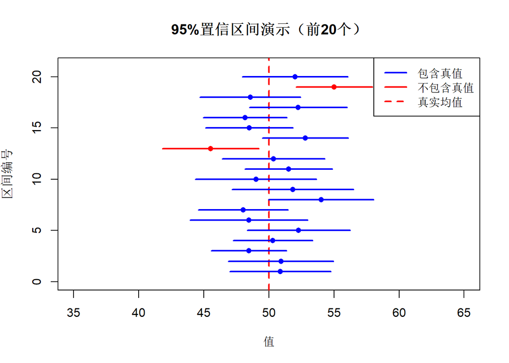

```r
# 可视化前20个区间
par(mar = c(5, 4, 4, 2))
plot(1, type = "n", xlim = c(35, 65), ylim = c(0, 21),
     main = "95%置信区间演示（前20个）",
     xlab = "值", ylab = "区间编号")
abline(v = true_mu, col = "red", lwd = 2, lty = 2)

for (i in 1:20) {
  color <- ifelse(intervals[i, "lower"] <= true_mu & intervals[i, "upper"] >= true_mu,
                  "blue", "red")
  segments(intervals[i, "lower"], i, intervals[i, "upper"], i, col = color, lwd = 2)
  points(intervals[i, "mean"], i, pch = 16, col = color)
}

legend("topright", legend = c("包含真值", "不包含真值", "真实均值"),
       col = c("blue", "red", "red"), lty = c(1, 1, 2), lwd = c(2, 2, 2))
```

## 3.4 单个总体均值的置信区间

### 3.4.1 Z区间（总体方差已知或大样本）

**数学公式**：
$$\bar{X} \pm
z_{\alpha/2} \cdot \frac{\sigma}{\sqrt{n}}$$

**适用条件**： - 总体方差已知，或 - 大样本（n ≥ 30）可用样本标准差代替

```r
# Z区间示例
# 假设已知总体标准差为10，估计均值的置信区间

set.seed(888)
sample_data <- rnorm(50, mean = 100, sd = 10)
n <- length(sample_data)
sample_mean <- mean(sample_data)
known_sigma <- 10  # 已知总体标准差

# 手动计算95%置信区间
z_critical <- qnorm(0.975)
se <- known_sigma / sqrt(n)
ci_lower <- sample_mean - z_critical * se
ci_upper <- sample_mean + z_critical * se

cat("样本均值:", sample_mean, "\n")
```

```
## 样本均值: 99.40236
```

```r
cat("95%置信区间: [", ci_lower, ",", ci_upper, "]\n")
```

```
## 95%置信区间: [ 96.63055 , 102.1742 ]
```

```r
# 大样本情况（用样本标准差）
sample_sd <- sd(sample_data)
se_sample <- sample_sd / sqrt(n)
ci_lower_large <- sample_mean - z_critical * se_sample
ci_upper_large <- sample_mean + z_critical * se_sample

cat("\n大样本近似（用样本标准差）:\n")
```

```
##
## 大样本近似（用样本标准差）:
```

```r
cat("95%置信区间: [", ci_lower_large, ",", ci_upper_large, "]\n")
```

```
## 95%置信区间: [ 96.3753 , 102.4294 ]
```

### 3.4.2 t区间（总体方差未知，小样本）

**数学公式**：
$$\bar{X} \pm
t_{\alpha/2, n-1} \cdot \frac{s}{\sqrt{n}}$$

**适用条件**： - 总体方差未知 - 小样本（n < 30） - 总体近似正态分布

```r
# t区间示例
set.seed(999)
small_sample <- rnorm(15, mean = 50, sd = 8)
n <- length(small_sample)

# 手动计算
sample_mean <- mean(small_sample)
sample_sd <- sd(small_sample)
t_critical <- qt(0.975, df = n - 1)
se <- sample_sd / sqrt(n)

ci_lower <- sample_mean - t_critical * se
ci_upper <- sample_mean + t_critical * se

cat("样本均值:", sample_mean, "\n")
```

```
## 样本均值: 48.35829
```

```r
cat("样本标准差:", sample_sd, "\n")
```

```
## 样本标准差: 7.76903
```

```r
cat("t临界值:", t_critical, "\n")
```

```
## t临界值: 2.144787
```

```r
cat("95%置信区间: [", ci_lower, ",", ci_upper, "]\n")
```

```
## 95%置信区间: [ 44.05595 , 52.66064 ]
```

```r
# 使用R内置函数t.test计算
t_result <- t.test(small_sample)
t_result
```

```
##
##  One Sample t-test
##
## data:  small_sample
## t = 24.107, df = 14, p-value = 8.435e-13
## alternative hypothesis: true mean is not equal to 0
## 95 percent confidence interval:
##  44.05595 52.66064
## sample estimates:
## mean of x
##  48.35829
```

```r
# 提取置信区间
t_result$conf.int
```

```
## [1] 44.05595 52.66064
## attr(,"conf.level")
## [1] 0.95
```

## 3.5 单个总体比例的置信区间

### 数学基础

**正态近似法**：
$$\hat{p}
\pm z_{\alpha/2}\sqrt{\frac{\hat{p}(1-\hat{p})}{n}}$$

适用条件：$n\hat{p} \geq 5$ 且 $n(1-\hat{p}) \geq 5$

**Wilson区间**（更精确）：
$$\frac{\hat{p} + \frac{z^2}{2n} \pm
z\sqrt{\frac{\hat{p}(1-\hat{p})}{n} + \frac{z^2}{4n^2}}}{1 +
\frac{z^2}{n}}$$

```r
# 比例的置信区间示例
# 某药物临床试验：100名患者中75人有效

n <- 100
successes <- 75
p_hat <- successes / n

# 方法1：正态近似
z_critical <- qnorm(0.975)
se <- sqrt(p_hat * (1 - p_hat) / n)
ci_normal <- c(p_hat - z_critical * se, p_hat + z_critical * se)
cat("正态近似法:\n")
```

```
## 正态近似法:
```

```r
cat("有效率:", p_hat, "\n")
```

```
## 有效率: 0.75
```

```r
cat("95%置信区间: [", ci_normal[1], ",", ci_normal[2], "]\n")
```

```
## 95%置信区间: [ 0.6651311 , 0.8348689 ]
```

```r
# 方法2：Wilson区间（推荐）
# 使用prop.test函数
prop_result <- prop.test(successes, n, correct = FALSE)
prop_result$conf.int
```

```
## [1] 0.6569554 0.8245479
## attr(,"conf.level")
## [1] 0.95
```

```r
# 方法3：精确二项分布区间（Clopper-Pearson）
binom_result <- binom.test(successes, n)
binom_result$conf.int
```

```
## [1] 0.6534475 0.8312203
## attr(,"conf.level")
## [1] 0.95
```

```r
# 比较三种方法
comparison_prop <- data.frame(
  方法 = c("正态近似", "Wilson", "Clopper-Pearson"),
  下限 = c(ci_normal[1], prop_result$conf.int[1], binom_result$conf.int[1]),
  上限 = c(ci_normal[2], prop_result$conf.int[2], binom_result$conf.int[2])
)
comparison_prop
```

```
##              方法      下限      上限
## 1        正态近似 0.6651311 0.8348689
## 2          Wilson 0.6569554 0.8245479
## 3 Clopper-Pearson 0.6534475 0.8312203
```

## 3.6 单个总体方差的置信区间

### 数学基础

基于卡方分布：
$$\left[\frac{(n-1)s^2}{\chi^2_{\alpha/2, n-1}},
\frac{(n-1)s^2}{\chi^2_{1-\alpha/2, n-1}}\right]$$

```r
# 方差的置信区间示例
set.seed(1111)
sample_data <- rnorm(30, mean = 100, sd = 15)
n <- length(sample_data)
sample_var <- var(sample_data)

# 手动计算
chi_lower <- qchisq(0.975, df = n - 1)
chi_upper <- qchisq(0.025, df = n - 1)

ci_var_lower <- (n - 1) * sample_var / chi_lower
ci_var_upper <- (n - 1) * sample_var / chi_upper

cat("样本方差:", sample_var, "\n")
```

```
## 样本方差: 306.5221
```

```r
cat("方差95%置信区间: [", ci_var_lower, ",", ci_var_upper, "]\n")
```

```
## 方差95%置信区间: [ 194.4159 , 553.9416 ]
```

```r
cat("标准差95%置信区间: [", sqrt(ci_var_lower), ",", sqrt(ci_var_upper), "]\n")
```

```
## 标准差95%置信区间: [ 13.94331 , 23.53596 ]
```

```r
# 使用DescTools包的VarCI函数
DescTools::VarCI(sample_data, method = "classic")
```

```
##      var   lwr.ci   upr.ci
## 306.5221 194.4159 553.9416
```

## 3.7 两个总体均值差的置信区间

### 3.7.1 独立样本

**方差相等时（ pooled variance ）**：
$$\bar{X}_1 - \bar{X}_2 \pm t_{\alpha/2, n_1+n_2-2}
\cdot s_p\sqrt{\frac{1}{n_1}+\frac{1}{n_2}}$$

其中 $s_p^2 = \frac{(n_1-1)s_1^2 + (n_2-1)s_2^2}{n_1+n_2-2}$

**方差不等时（Welch校正）**：
$$\bar{X}_1 - \bar{X}_2 \pm t_{\alpha/2, \nu} \cdot
\sqrt{\frac{s_1^2}{n_1}+\frac{s_2^2}{n_2}}$$

```r
# 两个独立样本均值差的置信区间
set.seed(2222)
group1 <- rnorm(25, mean = 100, sd = 15)
group2 <- rnorm(30, mean = 110, sd = 15)

# 使用t.test计算
# 方差相等假设
t_equal <- t.test(group1, group2, var.equal = TRUE)
t_equal
```

```
##
##  Two Sample t-test
##
## data:  group1 and group2
## t = -0.92681, df = 53, p-value = 0.3582
## alternative hypothesis: true difference in means is not equal to 0
## 95 percent confidence interval:
##  -11.612622   4.272472
## sample estimates:
## mean of x mean of y
##  104.0225  107.6926
```

```r
# 方差不等假设（Welch校正，默认）
t_welch <- t.test(group1, group2, var.equal = FALSE)
t_welch
```

```
##
##  Welch Two Sample t-test
##
## data:  group1 and group2
## t = -0.89579, df = 41.033, p-value = 0.3756
## alternative hypothesis: true difference in means is not equal to 0
## 95 percent confidence interval:
##  -11.943996   4.603847
## sample estimates:
## mean of x mean of y
##  104.0225  107.6926
```

```r
# 提取置信区间
cat("\n方差相等假设下的均值差置信区间:\n")
```

```
##
## 方差相等假设下的均值差置信区间:
```

```r
t_equal$conf.int
```

```
## [1] -11.612622   4.272472
## attr(,"conf.level")
## [1] 0.95
```

```r
cat("\n方差不等假设下的均值差置信区间:\n")
```

```
##
## 方差不等假设下的均值差置信区间:
```

```r
t_welch$conf.int
```

```
## [1] -11.943996   4.603847
## attr(,"conf.level")
## [1] 0.95
```

### 3.7.2 配对样本

**数学公式**：
$$\bar{d} \pm
t_{\alpha/2, n-1} \cdot \frac{s_d}{\sqrt{n}}$$

其中d为配对差值。

```r
# 配对样本均值差的置信区间
set.seed(3333)
# 治疗前后的血压数据
before <- rnorm(20, mean = 140, sd = 10)
after <- before - rnorm(20, mean = 8, sd = 5)  # 治疗后血压下降

# 使用t.test（配对）
t_paired <- t.test(before, after, paired = TRUE)
t_paired
```

```
##
##  Paired t-test
##
## data:  before and after
## t = 10.167, df = 19, p-value = 4.026e-09
## alternative hypothesis: true mean difference is not equal to 0
## 95 percent confidence interval:
##   7.06303 10.72480
## sample estimates:
## mean difference
##        8.893917
```

```r
# 手动计算
differences <- before - after
mean_diff <- mean(differences)
sd_diff <- sd(differences)
n <- length(differences)

t_crit <- qt(0.975, df = n - 1)
ci_diff <- mean_diff + c(-1, 1) * t_crit * sd_diff / sqrt(n)

cat("\n手动计算结果:\n")
```

```
##
## 手动计算结果:
```

```r
cat("平均差值:", mean_diff, "\n")
```

```
## 平均差值: 8.893917
```

```r
cat("差值95%置信区间: [", ci_diff[1], ",", ci_diff[2], "]\n")
```

```
## 差值95%置信区间: [ 7.06303 , 10.7248 ]
```

## 3.8 两个总体比例差的置信区间

### 数学基础

**正态近似**：
$$(\hat{p}_1 -
\hat{p}_2) \pm z_{\alpha/2}\sqrt{\frac{\hat{p}_1(1-\hat{p}_1)}{n_1} +
\frac{\hat{p}_2(1-\hat{p}_2)}{n_2}}$$

```r
# 两个比例差的置信区间
# 两组治疗效果比较
# 治疗组：80人有效，共100人
# 对照组：60人有效，共100人

# 使用prop.test
prop_comparison <- prop.test(c(80, 60), c(100, 100))
prop_comparison
```

```
##
##  2-sample test for equality of proportions with continuity correction
##
## data:  c(80, 60) out of c(100, 100)
## X-squared = 8.5952, df = 1, p-value = 0.00337
## alternative hypothesis: two.sided
## 95 percent confidence interval:
##  0.06604099 0.33395901
## sample estimates:
## prop 1 prop 2
##    0.8    0.6
```

```r
# 提取比例差置信区间
prop_comparison$conf.int
```

```
## [1] 0.06604099 0.33395901
## attr(,"conf.level")
## [1] 0.95
```

```r
# 手动计算
p1 <- 80/100
p2 <- 60/100
n1 <- n2 <- 100

diff <- p1 - p2
se_diff <- sqrt(p1*(1-p1)/n1 + p2*(1-p2)/n2)
z_crit <- qnorm(0.975)

ci_diff_prop <- diff + c(-1, 1) * z_crit * se_diff
cat("\n手动计算:\n")
```

```
##
## 手动计算:
```

```r
cat("比例差:", diff, "\n")
```

```
## 比例差: 0.2
```

```r
cat("95%置信区间: [", ci_diff_prop[1], ",", ci_diff_prop[2], "]\n")
```

```
## 95%置信区间: [ 0.07604099 , 0.323959 ]
```

## 3.9 自举法（Bootstrap）置信区间

### 数学基础

自举法是一种非参数方法，通过有放回重抽样来估计统计量的分布。

**基本步骤**： 1. 从原始样本中有放回抽取n个观测值（重抽样） 2. 计算感兴趣的统计量 3. 重复步骤1-2 B次（如1000次） 4. 用统计量的经验分布构建置信区间

**适用场景**： - 统计量的理论分布难以推导 - 小样本 - 复杂统计量（如中位数、相关系数）

```r
# Bootstrap置信区间示例
set.seed(4444)
original_sample <- rnorm(30, mean = 50, sd = 10)

# 使用boot包进行bootstrap
# 定义统计量函数
mean_fun <- function(data, indices) {
  return(mean(data[indices]))
}

# 进行bootstrap
boot_result <- boot::boot(data = original_sample,
                          statistic = mean_fun,
                          R = 1000)
boot_result
```

```
##
## ORDINARY NONPARAMETRIC BOOTSTRAP
##
##
## Call:
## boot::boot(data = original_sample, statistic = mean_fun, R = 1000)
##
##
## Bootstrap Statistics :
##     original     bias    std. error
## t1* 51.37265 0.05731496    1.982868
```

```r
# 计算不同类型的置信区间
boot_ci <- boot::boot.ci(boot_result, type = c("norm", "perc", "bca"))
boot_ci
```

```
## BOOTSTRAP CONFIDENCE INTERVAL CALCULATIONS
## Based on 1000 bootstrap replicates
##
## CALL :
## boot::boot.ci(boot.out = boot_result, type = c("norm", "perc",
##     "bca"))
##
## Intervals :
## Level      Normal             Percentile            BCa
## 95%   (47.43, 55.20 )   (47.70, 55.29 )   (47.71, 55.30 )
## Calculations and Intervals on Original Scale
```

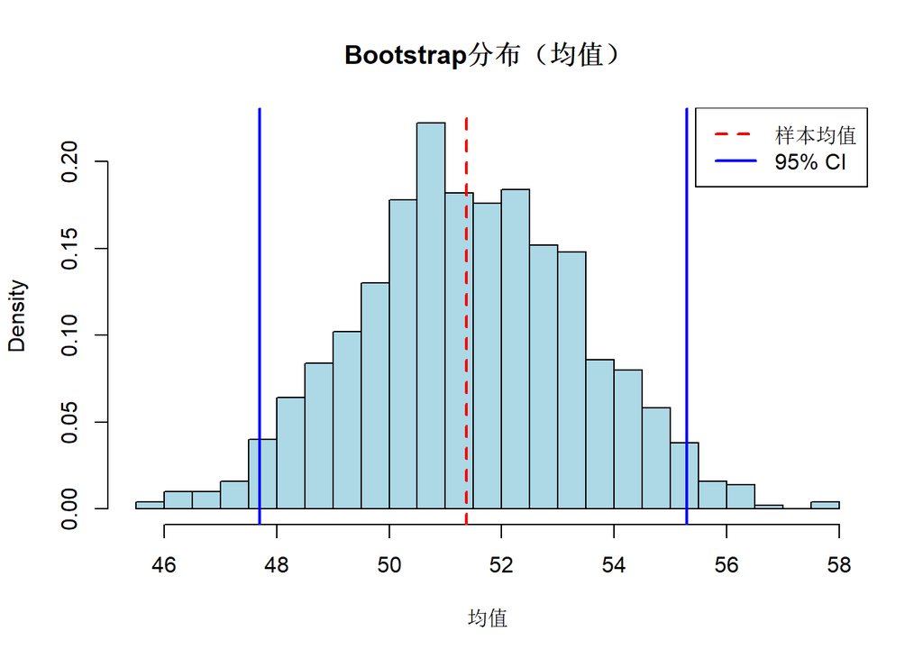

```r
# 可视化bootstrap分布
hist(boot_result$t, breaks = 30, main = "Bootstrap分布（均值）",
     xlab = "均值", col = "lightblue", probability = TRUE)
abline(v = mean(original_sample), col = "red", lwd = 2, lty = 2)
abline(v = boot_ci$percent[4:5], col = "blue", lwd = 2)
legend("topright", legend = c("样本均值", "95% CI"),
       col = c("red", "blue"), lty = c(2, 1), lwd = 2)
```

```r
# Bootstrap用于中位数（理论分布复杂）
median_fun <- function(data, indices) {
  return(median(data[indices]))
}

boot_median <- boot::boot(data = original_sample,
                          statistic = median_fun,
                          R = 1000)
boot_median_ci <- boot::boot.ci(boot_median, type = "perc")
cat("\n中位数的Bootstrap置信区间:\n")
```

```
##
## 中位数的Bootstrap置信区间:
```

```r
boot_median_ci
```

```
## BOOTSTRAP CONFIDENCE INTERVAL CALCULATIONS
## Based on 1000 bootstrap replicates
##
## CALL :
## boot::boot.ci(boot.out = boot_median, type = "perc")
##
## Intervals :
## Level     Percentile
## 95%   (46.07, 57.11 )
## Calculations and Intervals on Original Scale
```

## 3.10 贝叶斯可信区间简介

### 数学基础

**贝叶斯公式**：
$$P(\theta|data) =
\frac{P(data|\theta)P(\theta)}{P(data)}$$

**可信区间**： 参数θ的95%可信区间表示：参数有95%的概率落在此区间内。

**与置信区间的区别**： - 置信区间：频率学派，针对抽样过程 - 可信区间：贝叶斯学派，针对参数本身

```r
# 贝叶斯可信区间简单示例
# 使用共轭先验估计正态分布均值

# 假设：已知总体方差σ² = 100
# 先验：μ ~ N(μ₀, τ₀²)，其中μ₀ = 50, τ₀² = 25

# 数据
set.seed(5555)
sample_data <- rnorm(20, mean = 60, sd = 10)
n <- length(sample_data)
sample_mean <- mean(sample_data)

# 已知参数
sigma2 <- 100  # 总体方差
mu0 <- 50      # 先验均值
tau0_2 <- 25   # 先验方差

# 后验分布参数（共轭更新）
# 后验均值是先验均值和样本均值的加权平均
posterior_var <- 1 / (1/tau0_2 + n/sigma2)
posterior_mean <- posterior_var * (mu0/tau0_2 + n*sample_mean/sigma2)

cat("先验均值:", mu0, "\n")
```

```
## 先验均值: 50
```

```r
cat("样本均值:", sample_mean, "\n")
```

```
## 样本均值: 60.30519
```

```r
cat("后验均值:", posterior_mean, "\n")
```

```
## 后验均值: 58.58766
```

```r
cat("后验标准差:", sqrt(posterior_var), "\n")
```

```
## 后验标准差: 2.041241
```

```r
# 95%可信区间
bayesian_ci <- posterior_mean + c(-1, 1) * qnorm(0.975) * sqrt(posterior_var)
cat("95%贝叶斯可信区间: [", bayesian_ci[1], ",", bayesian_ci[2], "]\n")
```

```
## 95%贝叶斯可信区间: [ 54.5869 , 62.58842 ]
```

```r
# 与频率学派置信区间比较
freq_ci <- sample_mean + c(-1, 1) * qt(0.975, df = n-1) * sd(sample_data)/sqrt(n)
cat("95%置信区间: [", freq_ci[1], ",", freq_ci[2], "]\n")
```

```
## 95%置信区间: [ 56.26757 , 64.34282 ]
```

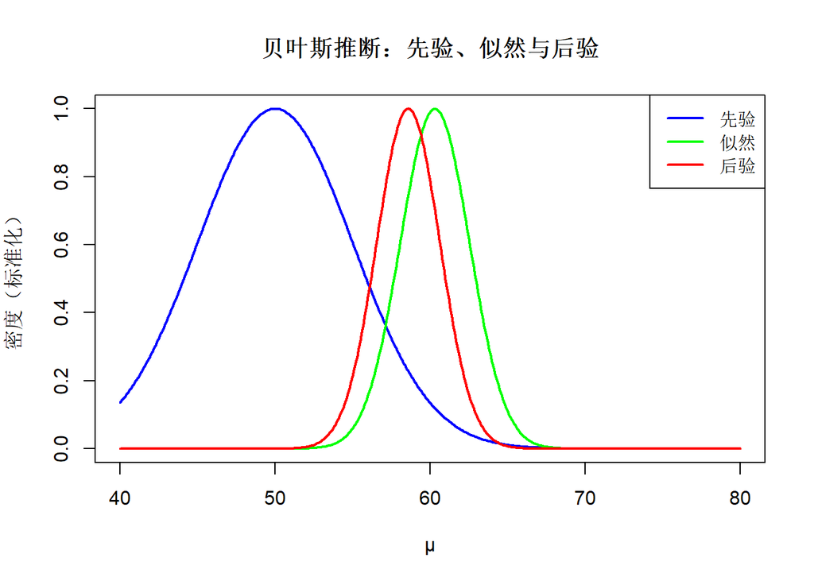

```r
# 可视化先验、似然和后验
x_range <- seq(40, 80, by = 0.1)
prior <- dnorm(x_range, mean = mu0, sd = sqrt(tau0_2))
likelihood <- dnorm(x_range, mean = sample_mean, sd = sqrt(sigma2/n))
posterior <- dnorm(x_range, mean = posterior_mean, sd = sqrt(posterior_var))

# 标准化便于比较
prior <- prior / max(prior)
likelihood <- likelihood / max(likelihood)
posterior <- posterior / max(posterior)

plot(x_range, prior, type = "l", col = "blue", lwd = 2,
     main = "贝叶斯推断：先验、似然与后验",
     xlab = "μ", ylab = "密度（标准化）")
lines(x_range, likelihood, col = "green", lwd = 2)
lines(x_range, posterior, col = "red", lwd = 2)
legend("topright", legend = c("先验", "似然", "后验"),
       col = c("blue", "green", "red"), lwd = 2)
```

## 第三章小结

| 内容 | 方法 | R函数 |
| --- | --- | --- |
| 点估计 | 矩估计、MLE | mean(), var(), MASS::fitdistr() |
| 均值置信区间 | Z区间、t区间 | t.test() |
| 比例置信区间 | Wilson、精确法 | prop.test(), binom.test() |
| 方差置信区间 | 卡方分布 | DescTools::VarCI() |
| 均值差置信区间 | t检验 | t.test() |
| 比例差置信区间 | 正态近似 | prop.test() |
| Bootstrap | 重抽样 | boot::boot(), boot::boot.ci() |
| 贝叶斯区间 | 共轭先验 | 手动计算或专用包 |

# 第四章：假设检验基础

假设检验是统计推断的核心方法之一，它帮助我们基于样本数据对总体参数做出判断。本章将介绍假设检验的基本概念、原理和实施步骤。

**为什么需要假设检验？**

1. **科学决策**：判断某种治疗是否有效
2. **验证理论**：检验理论预测是否符合实际数据
3. **质量控制**：判断产品是否符合标准
4. **研究结论**：为研究发现提供统计学依据

## 4.1 原假设与备择假设

### 数学基础

**原假设（Null Hypothesis, H₀）**： - 通常表示”无效应”或”无差异” - 是我们试图拒绝的假设 - 例如：$H_0: \mu = \mu_0$（总体均值等于某值）

**备择假设（Alternative Hypothesis, H₁或Hₐ）**： - 表示存在效应或差异 - 是我们试图支持的假设 - 例如：$H_1: \mu \neq \mu_0$（总体均值不等于某值）

### 假设检验的逻辑

假设检验采用”反证法”思想： 1. 假设H₀为真 2. 计算在H₀成立条件下，观测到当前数据（或更极端情况）的概率 3. 如果这个概率很小，则拒绝H₀

```r
# 假设检验基本概念示例
# 场景：某药物声称能降低血压
# 原假设 H₀: 药物无效（血压变化均值 = 0）
# 备择假设 H₁: 药物有效（血压变化均值 ≠ 0）

set.seed(6666)
# 假设我们观测到以下血压变化数据
bp_change <- c(-8, -5, -12, -3, -7, -10, -6, -4, -9, -11,
               -2, -8, -7, -5, -13, -6, -9, -4, -8, -10)

# 样本统计量
n <- length(bp_change)
sample_mean <- mean(bp_change)
sample_sd <- sd(bp_change)

cat("样本量:", n, "\n")
```

```
## 样本量: 20
```

```r
cat("样本均值:", sample_mean, "\n")
```

```
## 样本均值: -7.35
```

```r
cat("样本标准差:", sample_sd, "\n")
```

```
## 样本标准差: 3.013566
```

```r
# 进行单样本t检验
# H₀: μ = 0 vs H₁: μ ≠ 0
t_test_result <- t.test(bp_change, mu = 0)
t_test_result
```

```
##
##  One Sample t-test
##
## data:  bp_change
## t = -10.907, df = 19, p-value = 1.276e-09
## alternative hypothesis: true mean is not equal to 0
## 95 percent confidence interval:
##  -8.760392 -5.939608
## sample estimates:
## mean of x
##     -7.35
```

```r
# 提取关键信息
cat("\n假设检验结果解读:\n")
```

```
##
## 假设检验结果解读:
```

```r
cat("t统计量:", t_test_result$statistic, "\n")
```

```
## t统计量: -10.90741
```

```r
cat("自由度:", t_test_result$parameter, "\n")
```

```
## 自由度: 19
```

```r
cat("p值:", t_test_result$p.value, "\n")
```

```
## p值: 1.276243e-09
```

```r
cat("结论:", ifelse(t_test_result$p.value < 0.05,
                    "拒绝H₀，药物有效",
                    "不能拒绝H₀，证据不足"), "\n")
```

```
## 结论: 拒绝H₀，药物有效
```

## 4.2 检验统计量、拒绝域与显著性水平

### 数学基础

**检验统计量**： 将样本数据转换为标准化的统计量，用于判断是否拒绝H₀。

对于单样本t检验：
$$t = \frac{\bar{X} -
\mu_0}{s/\sqrt{n}}$$

**拒绝域**： 当检验统计量落入的区域，我们拒绝H₀。

**显著性水平（α）**： 犯第一类错误的最大允许概率，通常取0.05或0.01。

**临界值**： 拒绝域的边界值，由显著性水平决定。

```r
# 演示检验统计量、拒绝域和显著性水平

# 参数设置
alpha <- 0.05
df <- 19  # n-1 = 20-1

# 计算临界值（双侧检验）
t_critical <- qt(1 - alpha/2, df = df)
cat("显著性水平 α =", alpha, "\n")
```

```
## 显著性水平 α = 0.05
```

```r
cat("双侧检验临界值: ±", t_critical, "\n")
```

```
## 双侧检验临界值: ± 2.093024
```

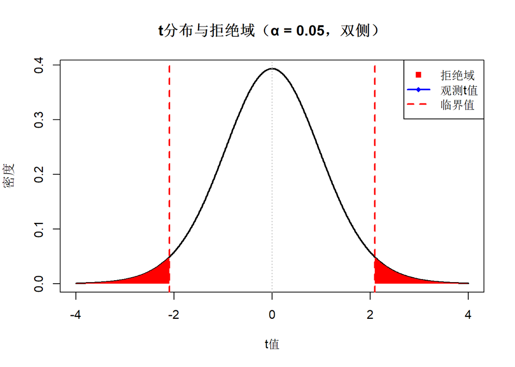

```r
# 可视化拒绝域
x <- seq(-4, 4, by = 0.01)
y <- dt(x, df = df)

plot(x, y, type = "l", lwd = 2, col = "black",
     main = "t分布与拒绝域（α = 0.05，双侧）",
     xlab = "t值", ylab = "密度")

# 标记拒绝域
x_left <- seq(-4, -t_critical, by = 0.01)
x_right <- seq(t_critical, 4, by = 0.01)
polygon(c(-4, x_left, -t_critical),
        c(0, dt(x_left, df = df), 0),
        col = "red", border = NA)
polygon(c(t_critical, x_right, 4),
        c(0, dt(x_right, df = df), 0),
        col = "red", border = NA)

# 添加临界值线
abline(v = c(-t_critical, t_critical), col = "red", lty = 2, lwd = 2)
abline(v = 0, col = "gray", lty = 3)

# 标记观测的t值
observed_t <- t_test_result$statistic
abline(v = observed_t, col = "blue", lwd = 2)
points(observed_t, 0, pch = 18, col = "blue", cex = 2)

legend("topright",
       legend = c("拒绝域", "观测t值", "临界值"),
       col = c("red", "blue", "red"),
       lty = c(NA, 1, 2), pch = c(15, 18, NA), lwd = c(NA, 2, 2))
```

```r
# 判断是否拒绝H₀
cat("\n观测到的t统计量:", observed_t, "\n")
```

```
##
## 观测到的t统计量: -10.90741
```

```r
cat("是否在拒绝域内:", ifelse(abs(observed_t) > t_critical, "是，拒绝H₀", "否，不能拒绝H₀"), "\n")
```

```
## 是否在拒绝域内: 是，拒绝H₀
```

## 4.3 p值的概念与解释

### 数学基础

**p值定义**： 在H₀为真的条件下，观测到当前统计量或更极端值的概率。

$$p = P(T \geq |t_{obs}| |
H_0)$$

**p值的解释**： - p值越小，反对H₀的证据越强 - p < α：拒绝H₀ - p ≥ α：不能拒绝H₀

**重要提醒**： - p值不是H₀为真的概率 - p值不是效应大小的度量 - 统计显著 ≠ 实际重要

```r
# p值计算与可视化

# 使用之前的t检验结果
observed_t <- as.numeric(t_test_result$statistic)
df <- 19

# 手动计算p值（双侧）
p_value <- 2 * pt(-abs(observed_t), df = df)
cat("手动计算的p值:", p_value, "\n")
```

```
## 手动计算的p值: 1.276243e-09
```

```r
cat("t.test输出的p值:", t_test_result$p.value, "\n")
```

```
## t.test输出的p值: 1.276243e-09
```

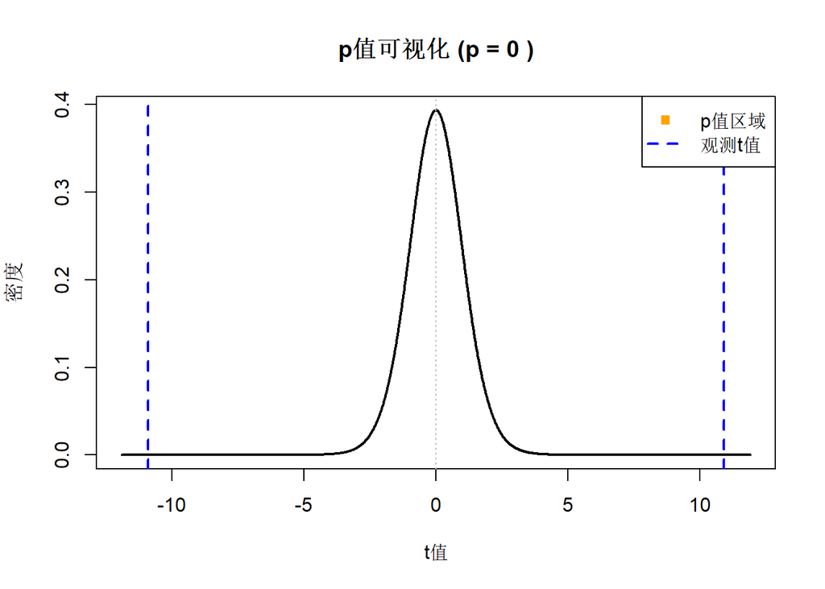

```r
# 可视化p值
# 确保x轴范围足够大以包含观测t值
x_range <- max(4, abs(observed_t) + 1)
x <- seq(-x_range, x_range, by = 0.01)
y <- dt(x, df = df)

plot(x, y, type = "l", lwd = 2, col = "black",
     main = paste("p值可视化 (p =", round(p_value, 6), ")"),
     xlab = "t值", ylab = "密度")

# 标记p值对应的区域
# 使用正确的seq方向
t_crit <- abs(observed_t)
if (t_crit < x_range) {
  x_p_left <- seq(-x_range, -t_crit, length.out = 100)
  x_p_right <- seq(t_crit, x_range, length.out = 100)

  polygon(c(-x_range, x_p_left, -t_crit),
          c(0, dt(x_p_left, df = df), 0),
          col = "orange", border = NA)
  polygon(c(t_crit, x_p_right, x_range),
          c(0, dt(x_p_right, df = df), 0),
          col = "orange", border = NA)
}

# 添加观测值线
abline(v = c(-t_crit, t_crit), col = "blue", lwd = 2, lty = 2)
abline(v = 0, col = "gray", lty = 3)

legend("topright",
       legend = c("p值区域", "观测t值"),
       col = c("orange", "blue"),
       lty = c(NA, 2), pch = c(15, NA), lwd = c(NA, 2))
```

```r
# p值与显著性水平比较
cat("\np值与显著性水平的比较:\n")
```

```
##
## p值与显著性水平的比较:
```

```r
cat("p值 =", p_value, "\n")
```

```
## p值 = 1.276243e-09
```

```r
cat("α = 0.05\n")
```

```
## α = 0.05
```

```r
cat("结论:", ifelse(p_value < 0.05, "p < α，拒绝H₀", "p ≥ α，不能拒绝H₀"), "\n")
```

```
## 结论: p < α，拒绝H₀
```

## 4.4 第I类错误与第II类错误

### 数学基础

|  | H₀为真 | H₀为假 |
| --- | --- | --- |
| **不拒绝H₀** | 正确决策 (1-α) | 第II类错误 (β) |
| **拒绝H₀** | 第I类错误 (α) | 正确决策 (1-β) |

**第I类错误（Type I Error）**： - 当H₀为真时错误地拒绝H₀ - 概率 = 显著性水平α - 也称为”假阳性”

**第II类错误（Type II Error）**： - 当H₀为假时未能拒绝H₀ - 概率 = β - 也称为”假阴性”

**检验功效（Power）**： - 正确拒绝错误H₀的概率 - Power = 1 - β

```r
# 演示两类错误

set.seed(7777)

# 设置参数
n <- 30
true_mu_null <- 100  # H₀下的均值
true_mu_alt <- 105   # 实际均值（H₁为真）
sigma <- 15
alpha <- 0.05
n_sim <- 1000

# 存储结果
reject_when_H0_true <- numeric(n_sim)  # H₀为真时的决策
reject_when_H1_true <- numeric(n_sim)  # H₁为真时的决策

for (i in 1:n_sim) {
  # H₀为真时的样本
  sample_H0 <- rnorm(n, mean = true_mu_null, sd = sigma)
  t_result_H0 <- t.test(sample_H0, mu = true_mu_null)
  reject_when_H0_true[i] <- ifelse(t_result_H0$p.value < alpha, 1, 0)

  # H₁为真时的样本
  sample_H1 <- rnorm(n, mean = true_mu_alt, sd = sigma)
  t_result_H1 <- t.test(sample_H1, mu = true_mu_null)
  reject_when_H1_true[i] <- ifelse(t_result_H1$p.value < alpha, 1, 0)
}

# 计算各类错误率
type1_error_rate <- mean(reject_when_H0_true)
type2_error_rate <- 1 - mean(reject_when_H1_true)
power <- mean(reject_when_H1_true)

cat("模拟结果（1000次）:\n")
```

```
## 模拟结果（1000次）:
```

```r
cat("第I类错误率（假阳性）:", type1_error_rate, "\n")
```

```
## 第I类错误率（假阳性）: 0.044
```

```r
cat("理论显著性水平 α:", alpha, "\n")
```

```
## 理论显著性水平 α: 0.05
```

```r
cat("第II类错误率（假阴性）:", type2_error_rate, "\n")
```

```
## 第II类错误率（假阴性）: 0.583
```

```r
cat("检验功效:", power, "\n")
```

```
## 检验功效: 0.417
```

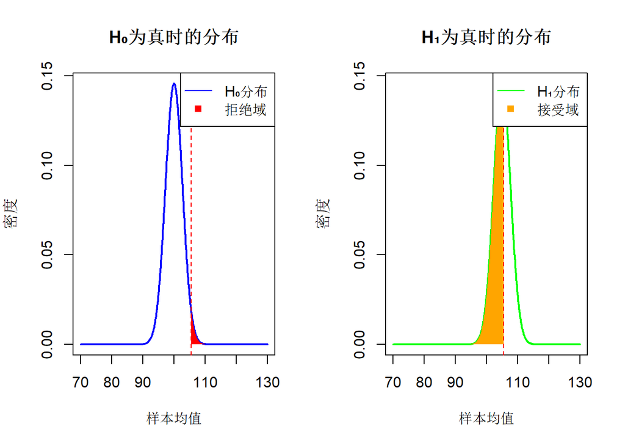

```r
# 可视化两类错误
par(mfrow = c(1, 2))

# H₀分布
x <- seq(70, 130, by = 0.1)
y_null <- dnorm(x, mean = true_mu_null, sd = sigma/sqrt(n))
plot(x, y_null, type = "l", lwd = 2, col = "blue",
     main = "H₀为真时的分布",
     xlab = "样本均值", ylab = "密度")
critical_value <- true_mu_null + qt(0.975, df = n-1) * sigma/sqrt(n)
x_reject <- seq(critical_value, 130, by = 0.1)
polygon(c(critical_value, x_reject, 130),
        c(0, dnorm(x_reject, mean = true_mu_null, sd = sigma/sqrt(n)), 0),
        col = "red", border = NA)
abline(v = critical_value, col = "red", lty = 2)
legend("topright", legend = c("H₀分布", "拒绝域"),
       col = c("blue", "red"), lty = c(1, NA), pch = c(NA, 15))

# H₁分布
y_alt <- dnorm(x, mean = true_mu_alt, sd = sigma/sqrt(n))
plot(x, y_alt, type = "l", lwd = 2, col = "green",
     main = "H₁为真时的分布",
     xlab = "样本均值", ylab = "密度")
x_accept <- seq(70, critical_value, by = 0.1)
polygon(c(70, x_accept, critical_value),
        c(0, dnorm(x_accept, mean = true_mu_alt, sd = sigma/sqrt(n)), 0),
        col = "orange", border = NA)
abline(v = critical_value, col = "red", lty = 2)
legend("topright", legend = c("H₁分布", "接受域"),
       col = c("green", "orange"), lty = c(1, NA), pch = c(NA, 15))
```

```r
par(mfrow = c(1, 1))
```

## 4.5 检验功效与样本量关系

### 数学基础

**功效与样本量的关系**： - 样本量越大，检验功效越高 - 效应量越大，检验功效越高 - 显著性水平越宽松（α越大），功效越高

**功效分析公式**（单样本t检验）：
$$n = \left(\frac{(z_{1-\alpha/2} +
z_{1-\beta})\sigma}{\delta}\right)^2$$

其中δ是期望检测的差异。

```r
# 功效与样本量关系演示

# 使用pwr包进行功效分析
# 单样本t检验

# 参数设置
effect_size <- 0.5  # 中等效应量 (Cohen's d)
alpha <- 0.05
power <- 0.8

# 计算所需样本量
sample_size_needed <- pwr::pwr.t.test(d = effect_size,
                                       sig.level = alpha,
                                       power = power,
                                       type = "one.sample")
sample_size_needed
```

```
##
##      One-sample t test power calculation
##
##               n = 33.36713
##               d = 0.5
##       sig.level = 0.05
##           power = 0.8
##     alternative = two.sided
```

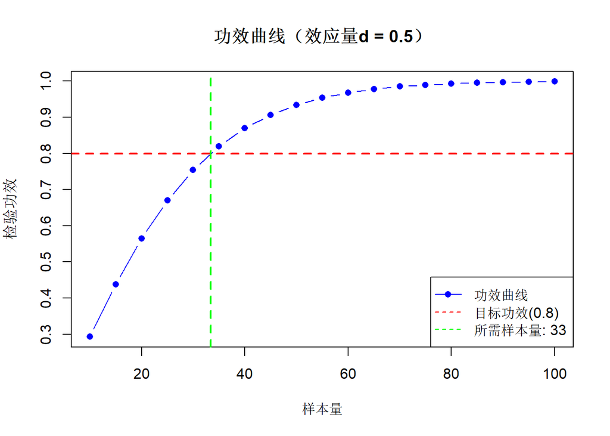

```r
# 不同样本量下的功效
sample_sizes <- seq(10, 100, by = 5)
power_values <- sapply(sample_sizes, function(n) {
  result <- pwr::pwr.t.test(d = effect_size,
                            sig.level = alpha,
                            n = n,
                            type = "one.sample")
  return(result$power)
})

# 可视化功效曲线
plot(sample_sizes, power_values, type = "b", pch = 16, col = "blue",
     main = "功效曲线（效应量d = 0.5）",
     xlab = "样本量", ylab = "检验功效")
abline(h = 0.8, col = "red", lty = 2, lwd = 2)
abline(v = sample_size_needed$n, col = "green", lty = 2, lwd = 2)
legend("bottomright",
       legend = c("功效曲线", "目标功效(0.8)", paste("所需样本量:", round(sample_size_needed$n))),
       col = c("blue", "red", "green"), lty = c(1, 2, 2), pch = c(16, NA, NA))
```

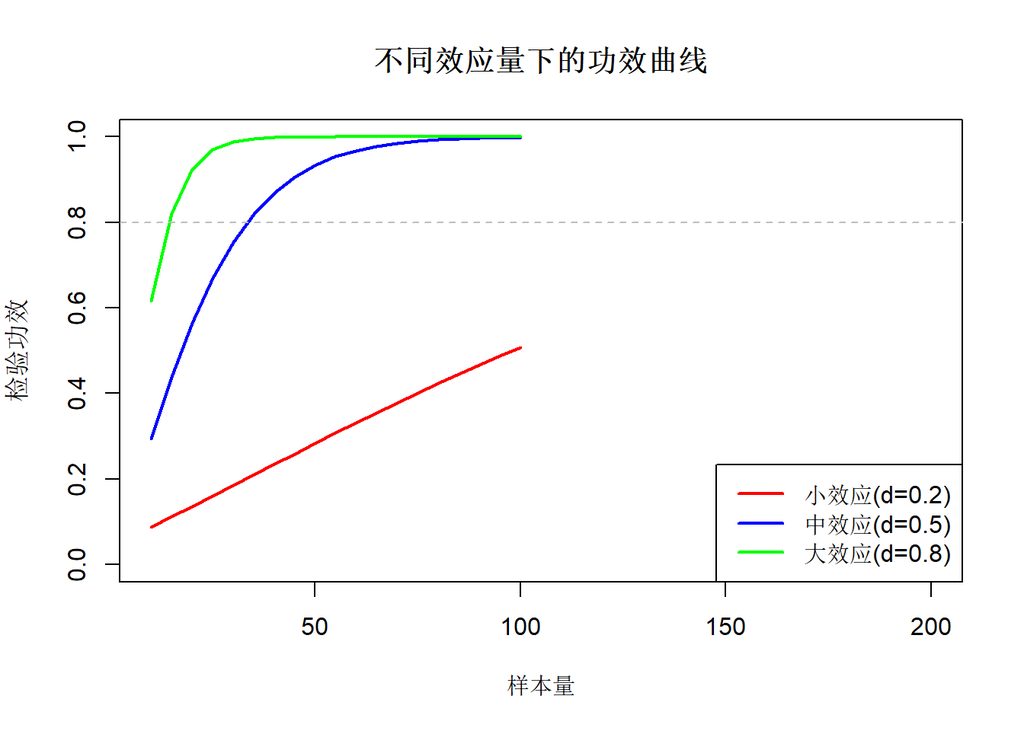

```r
# 不同效应量下的功效曲线
effect_sizes <- c(0.2, 0.5, 0.8)  # 小、中、大效应量
colors <- c("red", "blue", "green")
labels <- c("小效应(d=0.2)", "中效应(d=0.5)", "大效应(d=0.8)")

plot(NULL, xlim = c(10, 200), ylim = c(0, 1),
     main = "不同效应量下的功效曲线",
     xlab = "样本量", ylab = "检验功效")

for (i in seq_along(effect_sizes)) {
  power_vals <- sapply(sample_sizes, function(n) {
    result <- pwr::pwr.t.test(d = effect_sizes[i],
                              sig.level = alpha,
                              n = n,
                              type = "one.sample")
    return(result$power)
  })
  lines(seq(10, 100, by = 5), power_vals, col = colors[i], lwd = 2)
}

abline(h = 0.8, col = "gray", lty = 2)
legend("bottomright", legend = labels, col = colors, lwd = 2)
```

## 4.6 单侧检验与双侧检验

### 数学基础

**双侧检验**： - H₁: μ ≠ μ₀ - 拒绝域在分布两端 - 适用于不确定效应方向的情况

**单侧检验**： - H₁: μ > μ₀ 或 H₁: μ < μ₀ - 拒绝域在分布一端 - 适用于有明确方向假设的情况

```r
# 单侧与双侧检验比较

set.seed(8888)
sample_data <- rnorm(25, mean = 105, sd = 15)
mu_null <- 100

# 双侧检验
t_two_sided <- t.test(sample_data, mu = mu_null, alternative = "two.sided")
cat("双侧检验:\n")
```

```
## 双侧检验:
```

```r
cat("H₀: μ =", mu_null, "vs H₁: μ ≠", mu_null, "\n")
```

```
## H₀: μ = 100 vs H₁: μ ≠ 100
```

```r
cat("t统计量:", t_two_sided$statistic, "\n")
```

```
## t统计量: 2.787575
```

```r
cat("p值:", t_two_sided$p.value, "\n")
```

```
## p值: 0.01021967
```

```r
# 单侧检验（大于）
t_greater <- t.test(sample_data, mu = mu_null, alternative = "greater")
cat("\n单侧检验（大于）:\n")
```

```
##
## 单侧检验（大于）:
```

```r
cat("H₀: μ =", mu_null, "vs H₁: μ >", mu_null, "\n")
```

```
## H₀: μ = 100 vs H₁: μ > 100
```

```r
cat("t统计量:", t_greater$statistic, "\n")
```

```
## t统计量: 2.787575
```

```r
cat("p值:", t_greater$p.value, "\n")
```

```
## p值: 0.005109834
```

```r
# 单侧检验（小于）
t_less <- t.test(sample_data, mu = mu_null, alternative = "less")
cat("\n单侧检验（小于）:\n")
```

```
##
## 单侧检验（小于）:
```

```r
cat("H₀: μ =", mu_null, "vs H₁: μ <", mu_null, "\n")
```

```
## H₀: μ = 100 vs H₁: μ < 100
```

```r
cat("t统计量:", t_less$statistic, "\n")
```

```
## t统计量: 2.787575
```

```r
cat("p值:", t_less$p.value, "\n")
```

```
## p值: 0.9948902
```

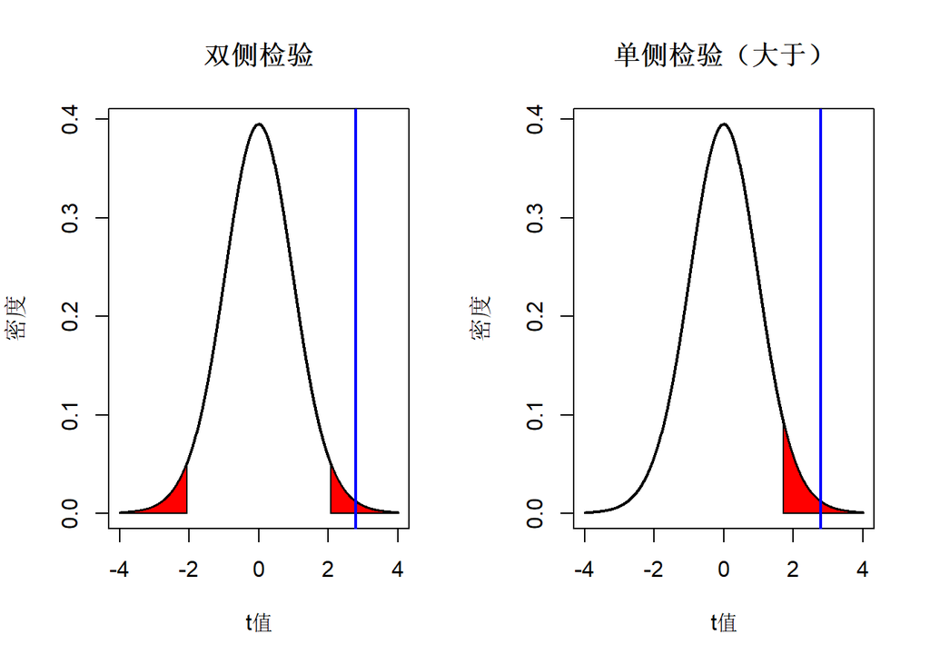

```r
# 可视化比较
par(mfrow = c(1, 2))

# 双侧检验
x <- seq(-4, 4, by = 0.01)
y <- dt(x, df = 24)
plot(x, y, type = "l", lwd = 2, main = "双侧检验",
     xlab = "t值", ylab = "密度")
t_crit_two <- qt(0.975, df = 24)
x_left <- seq(-4, -t_crit_two, by = 0.01)
x_right <- seq(t_crit_two, 4, by = 0.01)
polygon(c(-4, x_left, -t_crit_two), c(0, dt(x_left, 24), 0), col = "red")
polygon(c(t_crit_two, x_right, 4), c(0, dt(x_right, 24), 0), col = "red")
abline(v = t_two_sided$statistic, col = "blue", lwd = 2)

# 单侧检验
plot(x, y, type = "l", lwd = 2, main = "单侧检验（大于）",
     xlab = "t值", ylab = "密度")
t_crit_one <- qt(0.95, df = 24)
x_right <- seq(t_crit_one, 4, by = 0.01)
polygon(c(t_crit_one, x_right, 4), c(0, dt(x_right, 24), 0), col = "red")
abline(v = t_greater$statistic, col = "blue", lwd = 2)
```

```r
par(mfrow = c(1, 1))
```

## 4.7 效应量

### 数学基础

效应量衡量效应的实际大小，独立于样本量。常用的效应量包括：

**Cohen’s d**（均值差异）：
$$d = \frac{\bar{X}_1 -
\bar{X}_2}{s_{pooled}}$$

**Cramér’s V**（分类变量关联）：
$$V = \sqrt{\frac{\chi^2}{n(k-1)}}$$

**η²（Eta-squared）**（方差分析）：
$$\eta^2 =
\frac{SS_{between}}{SS_{total}}$$

### 效应量解释标准

| Cohen’s d | 效应大小 |
| --- | --- |
| 0.2 | 小 |
| 0.5 | 中 |
| 0.8 | 大 |

```r
# 效应量计算示例

# Cohen's d 计算
# 单样本
sample_mean <- mean(sample_data)
sample_sd <- sd(sample_data)
mu_null <- 100

cohens_d <- (sample_mean - mu_null) / sample_sd
cat("Cohen's d (单样本):", cohens_d, "\n")
```

```
## Cohen's d (单样本): 0.557515
```

```r
# 使用effectsize包（如果可用）或手动计算
# 双样本Cohen's d
set.seed(9999)
group1 <- rnorm(30, mean = 100, sd = 15)
group2 <- rnorm(30, mean = 110, sd = 15)

# 计算合并标准差
n1 <- length(group1)
n2 <- length(group2)
s1 <- sd(group1)
s2 <- sd(group2)
s_pooled <- sqrt(((n1-1)*s1^2 + (n2-1)*s2^2) / (n1 + n2 - 2))

# Cohen's d
d <- (mean(group2) - mean(group1)) / s_pooled
cat("Cohen's d (双样本):", d, "\n")
```

```
## Cohen's d (双样本): 0.127303
```

```r
# 效应量解释
if (abs(d) < 0.2) {
  effect_interpretation <- "极小效应"
} else if (abs(d) < 0.5) {
  effect_interpretation <- "小效应"
} else if (abs(d) < 0.8) {
  effect_interpretation <- "中等效应"
} else {
  effect_interpretation <- "大效应"
}
cat("效应量解释:", effect_interpretation, "\n")
```

```
## 效应量解释: 极小效应
```

```r
# 使用DescTools包计算效应量
# Cohen's d
DescTools::CohenD(group1, group2)
```

```
## [1] -0.127303
## attr(,"magnitude")
## [1] "negligible"
```

```r
# 相关性效应量（r）
# r = d / sqrt(d^2 + 4)
r_effect <- d / sqrt(d^2 + 4)
cat("\n相关性效应量 r:", r_effect, "\n")
```

```
##
## 相关性效应量 r: 0.06352294
```

```r
# 分类变量的效应量（Cramér's V）
# 创建列联表
contingency_table <- matrix(c(30, 10, 15, 45), nrow = 2)
rownames(contingency_table) <- c("治疗组", "对照组")
colnames(contingency_table) <- c("有效", "无效")
contingency_table
```

```
##        有效 无效
## 治疗组   30   15
## 对照组   10   45
```

```r
# 卡方检验
chi_test <- chisq.test(contingency_table)
chi_test
```

```
##
##  Pearson's Chi-squared test with Yates' continuity correction
##
## data:  contingency_table
## X-squared = 22.264, df = 1, p-value = 2.376e-06
```

```r
# 计算Cramér's V
n_total <- sum(contingency_table)
min_dim <- min(dim(contingency_table)) - 1
cramers_v <- sqrt(chi_test$statistic / (n_total * min_dim))
cat("Cramér's V:", cramers_v, "\n")
```

```
## Cramér's V: 0.4718507
```

```r
# 使用vcd包计算
vcd::assocstats(contingency_table)
```

```
##                     X^2 df   P(> X^2)
## Likelihood Ratio 25.161  1 5.2745e-07
## Pearson          24.242  1 8.4941e-07
##
## Phi-Coefficient   : 0.492
## Contingency Coeff.: 0.442
## Cramer's V        : 0.492
```

## 4.8 多重比较问题与校正

### 数学基础

**问题**：进行多次检验时，至少犯一次第I类错误的概率增加。

**族错误率（Family-wise Error Rate, FWER）**：
$$FWER = 1 - (1-\alpha)^m$$
其中m是检验次数。

**校正方法**：

1. **Bonferroni校正**：
   $$\alpha_{adjusted} =
   \frac{\alpha}{m}$$
2. **FDR（False Discovery Rate）**： 控制错误发现的比例，更宽松但更常用。

```r
# 多重比较问题演示

set.seed(11111)

# 模拟场景：检验5个变量是否与结果相关
# 假设所有变量实际上都与结果无关（H₀都为真）
n_tests <- 5
n_sim <- 1000
alpha <- 0.05

# 存储每次模拟中至少拒绝一次的比例
any_rejection <- numeric(n_sim)

for (i in 1:n_sim) {
  # 生成5个独立的随机变量
  p_values <- numeric(n_tests)
  for (j in 1:n_tests) {
    # 生成随机数据（H₀为真）
    x <- rnorm(50)
    y <- rnorm(50)
    # 计算相关性检验的p值
    p_values[j] <- cor.test(x, y)$p.value
  }
  # 是否至少有一个显著
  any_rejection[i] <- ifelse(any(p_values < alpha), 1, 0)
}

# 计算实际犯第I类错误的概率
fwer_simulated <- mean(any_rejection)
fwer_theoretical <- 1 - (1 - alpha)^n_tests

cat("模拟的族错误率:", fwer_simulated, "\n")
```

```
## 模拟的族错误率: 0.225
```

```r
cat("理论族错误率:", fwer_theoretical, "\n")
```

```
## 理论族错误率: 0.2262191
```

```r
cat("单次检验显著性水平:", alpha, "\n")
```

```
## 单次检验显著性水平: 0.05
```

```r
# 多重比较校正示例
# 假设我们进行了5次检验，得到以下p值
observed_pvalues <- c(0.01, 0.03, 0.04, 0.12, 0.25)

# Bonferroni校正
bonferroni_adjusted <- p.adjust(observed_pvalues, method = "bonferroni")
cat("\nBonferroni校正:\n")
```

```
##
## Bonferroni校正:
```

```r
cat("原始p值:", observed_pvalues, "\n")
```

```
## 原始p值: 0.01 0.03 0.04 0.12 0.25
```

```r
cat("校正后p值:", bonferroni_adjusted, "\n")
```

```
## 校正后p值: 0.05 0.15 0.2 0.6 1
```

```r
# FDR校正（Benjamini-Hochberg）
fdr_adjusted <- p.adjust(observed_pvalues, method = "BH")
cat("\nFDR校正:\n")
```

```
##
## FDR校正:
```

```r
cat("原始p值:", observed_pvalues, "\n")
```

```
## 原始p值: 0.01 0.03 0.04 0.12 0.25
```

```r
cat("校正后p值:", fdr_adjusted, "\n")
```

```
## 校正后p值: 0.05 0.06666667 0.06666667 0.15 0.25
```

```r
# 比较表格
comparison_table <- data.frame(
  检验 = paste("检验", 1:5),
  原始p值 = observed_pvalues,
  Bonferroni = bonferroni_adjusted,
  FDR = fdr_adjusted,
  Bonferroni显著 = ifelse(bonferroni_adjusted < 0.05, "是", "否"),
  FDR显著 = ifelse(fdr_adjusted < 0.05, "是", "否")
)
comparison_table
```

```
##     检验 原始p值 Bonferroni        FDR Bonferroni显著 FDR显著
## 1 检验 1    0.01       0.05 0.05000000             否      否
## 2 检验 2    0.03       0.15 0.06666667             否      否
## 3 检验 3    0.04       0.20 0.06666667             否      否
## 4 检验 4    0.12       0.60 0.15000000             否      否
## 5 检验 5    0.25       1.00 0.25000000             否      否
```

## 第四章小结

| 概念 | 定义 | 说明 |
| --- | --- | --- |
| 原假设H₀ | 无效应假设 | 试图拒绝的假设 |
| 备择假设H₁ | 有效应假设 | 试图支持的假设 |
| p值 | H₀为真时观测到极端值的概率 | p < α 拒绝H₀ |
| 第I类错误 | H₀为真时拒绝H₀ | 概率 = α |
| 第II类错误 | H₀为假时不拒绝H₀ | 概率 = β |
| 检验功效 | 正确拒绝错误H₀ | Power = 1-β |
| 效应量 | 效应的实际大小 | 独立于样本量 |
| 多重比较校正 | 控制族错误率 | Bonferroni, FDR |

# 第五章：常见参数检验

参数检验是在总体分布形式已知（通常假设正态分布）的条件下进行的假设检验。本章将介绍最常用的参数检验方法及其在R中的实现。

**参数检验的前提条件**： 1. 数据来自正态分布（或样本量足够大） 2. 样本是独立随机样本 3. 方差齐性（对于多组比较）

## 5.1 单样本t检验

### 数学基础

检验样本均值是否与已知的总体均值有显著差异。

**检验统计量**：
$$t =
\frac{\bar{X} - \mu_0}{s/\sqrt{n}}$$

**假设**： - H₀: μ = μ₀ - H₁: μ ≠ μ₀（双侧）或 μ > μ₀ / μ < μ₀（单侧）

**适用条件**： - 样本来自正态分布总体 - 或样本量足够大（n ≥ 30）

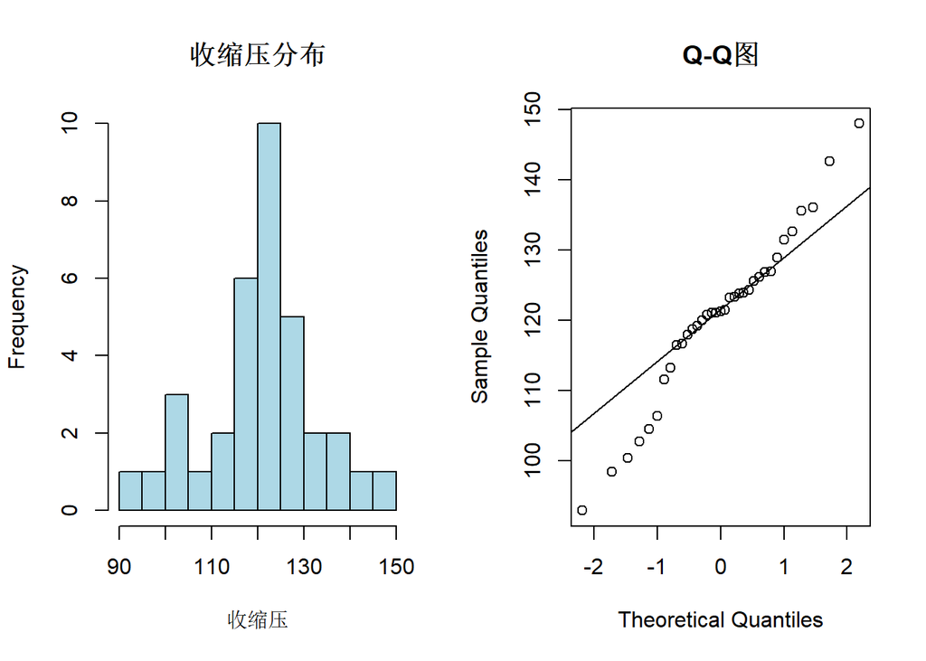

```r
# 单样本t检验示例
# 场景：检验某地区成人平均收缩压是否为120 mmHg

set.seed(12121)
# 生成样本数据
sbp_data <- rnorm(35, mean = 125, sd = 12)

# 检查正态性
par(mfrow = c(1, 2))
hist(sbp_data, breaks = 10, main = "收缩压分布", xlab = "收缩压", col = "lightblue")
qqnorm(sbp_data, main = "Q-Q图")
qqline(sbp_data)
```

```r
par(mfrow = c(1, 1))

# Shapiro-Wilk正态性检验
shapiro.test(sbp_data)
```

```
##
##  Shapiro-Wilk normality test
##
## data:  sbp_data
## W = 0.96795, p-value = 0.3894
```

```r
# 单样本t检验
# H₀: μ = 120 vs H₁: μ ≠ 120
t_test_one <- t.test(sbp_data, mu = 120)
t_test_one
```

```
##
##  One Sample t-test
##
## data:  sbp_data
## t = 0.33033, df = 34, p-value = 0.7432
## alternative hypothesis: true mean is not equal to 120
## 95 percent confidence interval:
##  116.5646 124.7689
## sample estimates:
## mean of x
##  120.6668
```

```r
# 提取关键信息
cat("\n检验结果解读:\n")
```

```
##
## 检验结果解读:
```

```r
cat("样本均值:", mean(sbp_data), "\n")
```

```
## 样本均值: 120.6668
```

```r
cat("t统计量:", t_test_one$statistic, "\n")
```

```
## t统计量: 0.3303258
```

```r
cat("自由度:", t_test_one$parameter, "\n")
```

```
## 自由度: 34
```

```r
cat("p值:", t_test_one$p.value, "\n")
```

```
## p值: 0.7431807
```

```r
cat("95%置信区间:", t_test_one$conf.int, "\n")
```

```
## 95%置信区间: 116.5646 124.7689
```

```r
cat("结论:", ifelse(t_test_one$p.value < 0.05,
                    "拒绝H₀，收缩压均值显著不同于120",
                    "不能拒绝H₀"), "\n")
```

```
## 结论: 不能拒绝H₀
```

```r
# 效应量（Cohen's d）
cohens_d <- (mean(sbp_data) - 120) / sd(sbp_data)
cat("Cohen's d:", cohens_d, "\n")
```

```
## Cohen's d: 0.05583525
```

## 5.2 独立样本t检验

### 数学基础

检验两个独立样本的均值是否有显著差异。

**方差相等时（Student’s t-test）**：
$$t = \frac{\bar{X}_1 -
\bar{X}_2}{s_p\sqrt{\frac{1}{n_1} + \frac{1}{n_2}}}$$

其中 $s_p = \sqrt{\frac{(n_1-1)s_1^2 + (n_2-1)s_2^2}{n_1 + n_2 - 2}}$

**方差不等时（Welch’s t-test）**：
$$t = \frac{\bar{X}_1 -
\bar{X}_2}{\sqrt{\frac{s_1^2}{n_1} + \frac{s_2^2}{n_2}}}$$

```r
# 独立样本t检验示例
# 场景：比较新药组和安慰剂组的血压降低值

set.seed(22222)
# 生成数据
drug_group <- rnorm(25, mean = 15, sd = 6)   # 新药组血压降低值
placebo_group <- rnorm(25, mean = 8, sd = 6) # 安慰剂组血压降低值

# 创建数据框
bp_data <- data.frame(
  reduction = c(drug_group, placebo_group),
  group = factor(rep(c("Drug", "Placebo"), each = 25))
)

# 描述性统计
bp_data %>%
  dplyr::group_by(group) %>%
  dplyr::summarise(
    n = dplyr::n(),
    mean = mean(reduction),
    sd = sd(reduction),
    min = min(reduction),
    max = max(reduction)
  )
```

```
## # A tibble: 2 × 6
##   group       n  mean    sd   min   max
##   <fct>   <int> <dbl> <dbl> <dbl> <dbl>
## 1 Drug       25 14.2   6.28  5.06  26.3
## 2 Placebo    25  8.98  5.60  1.77  25.0
```

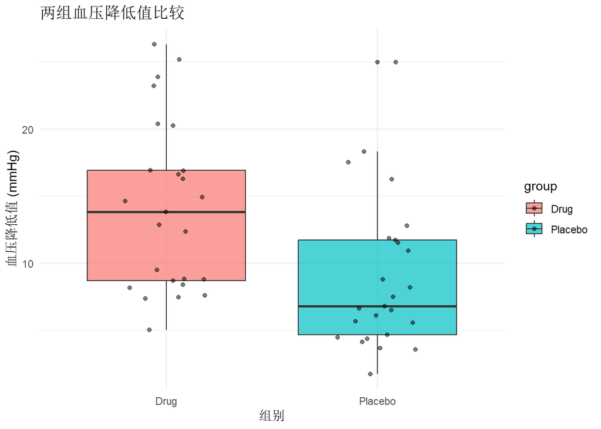

```r
# 可视化
ggplot2::ggplot(bp_data, ggplot2::aes(x = group, y = reduction, fill = group)) +
  ggplot2::geom_boxplot(alpha = 0.7) +
  ggplot2::geom_jitter(width = 0.2, alpha = 0.5) +
  ggplot2::labs(title = "两组血压降低值比较",
       x = "组别", y = "血压降低值 (mmHg)") +
  ggplot2::theme_minimal()
```

```r
# 检查正态性（每组）
by(bp_data$reduction, bp_data$group, shapiro.test)
```

```
## bp_data$group: Drug
##
##  Shapiro-Wilk normality test
##
## data:  dd[x, ]
## W = 0.92617, p-value = 0.07094
##
## ------------------------------------------------------------
## bp_data$group: Placebo
##
##  Shapiro-Wilk normality test
##
## data:  dd[x, ]
## W = 0.8888, p-value = 0.01055
```

```r
# 检查方差齐性
var_test <- var.test(reduction ~ group, data = bp_data)
var_test
```

```
##
##  F test to compare two variances
##
## data:  reduction by group
## F = 1.2592, num df = 24, denom df = 24, p-value = 0.5768
## alternative hypothesis: true ratio of variances is not equal to 1
## 95 percent confidence interval:
##  0.5548954 2.8574999
## sample estimates:
## ratio of variances
##           1.259211
```

```r
# 独立样本t检验
# 方差相等假设
t_equal <- t.test(reduction ~ group, data = bp_data, var.equal = TRUE)
t_equal
```

```
##
##  Two Sample t-test
##
## data:  reduction by group
## t = 3.0893, df = 48, p-value = 0.003333
## alternative hypothesis: true difference in means between group Drug and group Placebo is not equal to 0
## 95 percent confidence interval:
##  1.815993 8.585922
## sample estimates:
##    mean in group Drug mean in group Placebo
##             14.181663              8.980705
```

```r
# Welch校正（默认，更稳健）
t_welch <- t.test(reduction ~ group, data = bp_data, var.equal = FALSE)
t_welch
```

```
##
##  Welch Two Sample t-test
##
## data:  reduction by group
## t = 3.0893, df = 47.376, p-value = 0.003352
## alternative hypothesis: true difference in means between group Drug and group Placebo is not equal to 0
## 95 percent confidence interval:
##  1.814842 8.587074
## sample estimates:
##    mean in group Drug mean in group Placebo
##             14.181663              8.980705
```

```r
# 效应量（Cohen's d）
# 使用DescTools包
DescTools::CohenD(drug_group, placebo_group)
```

```
## [1] 0.8737906
## attr(,"magnitude")
## [1] "large"
```

```r
# 手动计算
s_pooled <- sqrt(((25-1)*sd(drug_group)^2 + (25-1)*sd(placebo_group)^2) / (25 + 25 - 2))
d_manual <- (mean(drug_group) - mean(placebo_group)) / s_pooled
cat("手动计算的Cohen's d:", d_manual, "\n")
```

```
## 手动计算的Cohen's d: 0.8737906
```

## 5.3 配对样本t检验

### 数学基础

检验配对数据（如治疗前后）的差异是否显著。

**检验统计量**：
$$t =
\frac{\bar{d}}{s_d/\sqrt{n}}$$

其中d是配对差值，$\bar{d}$是差值均值，$s_d$是差值标准差。

**适用场景**： - 治疗前后测量 - 同一受试者的两种测量方法 - 配对设计的实验

```r
# 配对样本t检验示例
# 场景：患者治疗前后的血压变化

set.seed(33333)
n <- 20
# 治疗前血压
before <- rnorm(n, mean = 145, sd = 12)
# 治疗后血压（假设平均下降10 mmHg）
after <- before - rnorm(n, mean = 10, sd = 5)

# 创建数据框
paired_data <- data.frame(
  patient = 1:n,
  before = before,
  after = after,
  diff = before - after
)

# 查看数据
head(paired_data)
```

```
##   patient   before    after      diff
## 1       1 158.6004 148.9063  9.694084
## 2       2 139.4294 128.3045 11.124910
## 3       3 127.3783 114.0198 13.358465
## 4       4 149.1485 130.5847 18.563822
## 5       5 141.2193 128.8387 12.380648
## 6       6 148.9844 134.7064 14.277963
```

```r
# 描述性统计
cat("治疗前均值:", mean(before), "\n")
```

```
## 治疗前均值: 141.9287
```

```r
cat("治疗后均值:", mean(after), "\n")
```

```
## 治疗后均值: 131.4311
```

```r
cat("平均差值:", mean(before - after), "\n")
```

```
## 平均差值: 10.49755
```

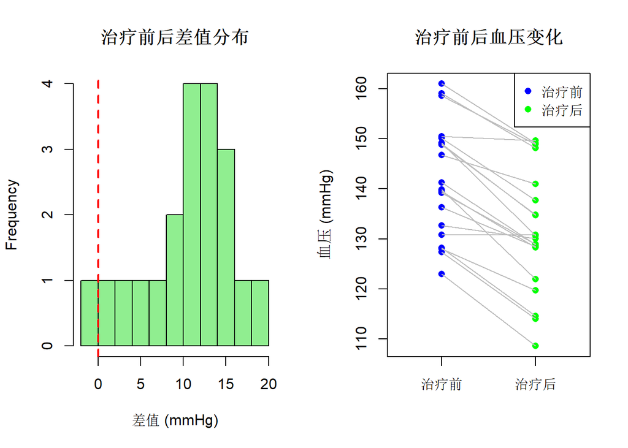

```r
# 可视化配对数据
# 差值的分布
par(mfrow = c(1, 2))
hist(paired_data$diff, breaks = 10, main = "治疗前后差值分布",
     xlab = "差值 (mmHg)", col = "lightgreen")
abline(v = 0, col = "red", lwd = 2, lty = 2)

# 配对连线图
plot(rep(1, n), before, xlim = c(0.5, 2.5), ylim = range(c(before, after)),
     main = "治疗前后血压变化", xlab = "", ylab = "血压 (mmHg)",
     xaxt = "n", pch = 16, col = "blue")
points(rep(2, n), after, pch = 16, col = "green")
segments(rep(1, n), before, rep(2, n), after, col = "gray")
axis(1, at = c(1, 2), labels = c("治疗前", "治疗后"))
legend("topright", legend = c("治疗前", "治疗后"),
       col = c("blue", "green"), pch = 16)
```

```r
par(mfrow = c(1, 1))

# 检查差值的正态性
shapiro.test(paired_data$diff)
```

```
##
##  Shapiro-Wilk normality test
##
## data:  paired_data$diff
## W = 0.93545, p-value = 0.1965
```

```r
# 配对t检验
# 方法1：使用两个向量
t_paired <- t.test(before, after, paired = TRUE)
t_paired
```

```
##
##  Paired t-test
##
## data:  before and after
## t = 9.2511, df = 19, p-value = 1.816e-08
## alternative hypothesis: true mean difference is not equal to 0
## 95 percent confidence interval:
##   8.122531 12.872569
## sample estimates:
## mean difference
##        10.49755
```

```r
# 方法2：使用差值
t_diff <- t.test(paired_data$diff, mu = 0)
t_diff
```

```
##
##  One Sample t-test
##
## data:  paired_data$diff
## t = 9.2511, df = 19, p-value = 1.816e-08
## alternative hypothesis: true mean is not equal to 0
## 95 percent confidence interval:
##   8.122531 12.872569
## sample estimates:
## mean of x
##  10.49755
```

```r
# 效应量
# 对于配对数据，使用差值的标准差
cohens_d_paired <- mean(paired_data$diff) / sd(paired_data$diff)
cat("配对数据的Cohen's d:", cohens_d_paired, "\n")
```

```
## 配对数据的Cohen's d: 2.068617
```

## 5.4 单样本比例检验

### 数学基础

检验样本比例是否与已知总体比例有显著差异。

**检验统计量**（大样本）：
$$z = \frac{\hat{p} -
p_0}{\sqrt{p_0(1-p_0)/n}}$$

**精确检验**：使用二项分布。

```r
# 单样本比例检验示例
# 场景：检验某疾病的治愈率是否为70%

# 数据：100名患者中80人治愈
n <- 100
successes <- 80
p_null <- 0.70

# 精确二项检验
binom_result <- binom.test(successes, n, p = p_null)
binom_result
```

```
##
##  Exact binomial test
##
## data:  successes and n
## number of successes = 80, number of trials = 100, p-value = 0.02896
## alternative hypothesis: true probability of success is not equal to 0.7
## 95 percent confidence interval:
##  0.7081573 0.8733444
## sample estimates:
## probability of success
##                    0.8
```

```r
# 正态近似检验
prop_result <- prop.test(successes, n, p = p_null, correct = FALSE)
prop_result
```

```
##
##  1-sample proportions test without continuity correction
##
## data:  successes out of n, null probability p_null
## X-squared = 4.7619, df = 1, p-value = 0.0291
## alternative hypothesis: true p is not equal to 0.7
## 95 percent confidence interval:
##  0.7111708 0.8666331
## sample estimates:
##   p
## 0.8
```

```r
# 带连续性校正
prop_corrected <- prop.test(successes, n, p = p_null, correct = TRUE)
prop_corrected
```

```
##
##  1-sample proportions test with continuity correction
##
## data:  successes out of n, null probability p_null
## X-squared = 4.2976, df = 1, p-value = 0.03817
## alternative hypothesis: true p is not equal to 0.7
## 95 percent confidence interval:
##  0.7056770 0.8707518
## sample estimates:
##   p
## 0.8
```

```r
# 比较结果
cat("\n三种方法比较:\n")
```

```
##
## 三种方法比较:
```

```r
cat("精确二项检验 p值:", binom_result$p.value, "\n")
```

```
## 精确二项检验 p值: 0.02896126
```

```r
cat("正态近似 p值:", prop_result$p.value, "\n")
```

```
## 正态近似 p值: 0.02909633
```

```r
cat("连续性校正 p值:", prop_corrected$p.value, "\n")
```

```
## 连续性校正 p值: 0.03816577
```

```r
# 单侧检验（治愈率是否高于70%）
prop_greater <- prop.test(successes, n, p = p_null,
                           alternative = "greater", correct = FALSE)
prop_greater
```

```
##
##  1-sample proportions test without continuity correction
##
## data:  successes out of n, null probability p_null
## X-squared = 4.7619, df = 1, p-value = 0.01455
## alternative hypothesis: true p is greater than 0.7
## 95 percent confidence interval:
##  0.7266962 1.0000000
## sample estimates:
##   p
## 0.8
```

## 5.5 两样本比例检验

### 数学基础

检验两个独立样本的比例是否有显著差异。

**检验统计量**：
$$z =
\frac{\hat{p}_1 - \hat{p}_2}{\sqrt{\hat{p}(1-\hat{p})(\frac{1}{n_1} +
\frac{1}{n_2})}}$$

其中 $\hat{p} = \frac{x_1 + x_2}{n_1 + n_2}$ 是合并比例。

```r
# 两样本比例检验示例
# 场景：比较两种治疗方法的治愈率

# 治疗组A：120人中95人治愈
# 治疗组B：110人中78人治愈

successes <- c(95, 78)
totals <- c(120, 110)

# 卡方检验（比例差异）
prop_comparison <- prop.test(successes, totals, correct = FALSE)
prop_comparison
```

```
##
##  2-sample test for equality of proportions without continuity correction
##
## data:  successes out of totals
## X-squared = 2.0994, df = 1, p-value = 0.1474
## alternative hypothesis: two.sided
## 95 percent confidence interval:
##  -0.02915428  0.19430579
## sample estimates:
##    prop 1    prop 2
## 0.7916667 0.7090909
```

```r
# 带Yates连续性校正
prop_yates <- prop.test(successes, totals, correct = TRUE)
prop_yates
```

```
##
##  2-sample test for equality of proportions with continuity correction
##
## data:  successes out of totals
## X-squared = 1.6797, df = 1, p-value = 0.195
## alternative hypothesis: two.sided
## 95 percent confidence interval:
##  -0.0378664  0.2030179
## sample estimates:
##    prop 1    prop 2
## 0.7916667 0.7090909
```

```r
# Fisher精确检验（小样本时推荐）
fisher_result <- fisher.test(matrix(c(95, 25, 78, 32), nrow = 2))
fisher_result
```

```
##
##  Fisher's Exact Test for Count Data
##
## data:  matrix(c(95, 25, 78, 32), nrow = 2)
## p-value = 0.1699
## alternative hypothesis: true odds ratio is not equal to 1
## 95 percent confidence interval:
##  0.8173419 2.9886143
## sample estimates:
## odds ratio
##   1.555915
```

```r
# 计算比例和置信区间
p1 <- 95/120
p2 <- 78/110
cat("治疗组A治愈率:", round(p1*100, 1), "%\n")
```

```
## 治疗组A治愈率: 79.2 %
```

```r
cat("治疗组B治愈率:", round(p2*100, 1), "%\n")
```

```
## 治疗组B治愈率: 70.9 %
```

```r
cat("比例差:", round((p1-p2)*100, 1), "%\n")
```

```
## 比例差: 8.3 %
```

```r
# 效应量（Odds Ratio）
or <- (95/25) / (78/32)
cat("Odds Ratio:", or, "\n")
```

```
## Odds Ratio: 1.558974
```

## 5.6 单样本方差检验

### 数学基础

检验总体方差是否等于某个特定值。

**检验统计量**：
$$\chi^2 =
\frac{(n-1)s^2}{\sigma_0^2}$$

服从自由度为n-1的卡方分布。

```r
# 单样本方差检验示例
# 场景：检验某生产过程的方差是否为100（标准差为10）

set.seed(44444)
sample_data <- rnorm(30, mean = 50, sd = 12)

# 假设检验
# H₀: σ² = 100 vs H₁: σ² ≠ 100
n <- length(sample_data)
sample_var <- var(sample_data)
null_var <- 100

# 卡方统计量
chi_sq <- (n - 1) * sample_var / null_var
chi_sq
```

```
## [1] 30.80413
```

```r
# p值（双侧）
p_value <- 2 * min(pchisq(chi_sq, df = n-1), 1 - pchisq(chi_sq, df = n-1))
p_value
```

```
## [1] 0.7494319
```

```r
# 使用DescTools包
DescTools::VarTest(sample_data, sigma.squared = 100)
```

[output not shown]

## 5.7 两样本方差比较（F检验）

### 数学基础

检验两个独立样本的方差是否相等。

**检验统计量**：
$$F =
\frac{s_1^2}{s_2^2}$$

服从自由度为$(n_1-1, n_2-1)$的F分布。

```r
# 两样本方差比较示例
set.seed(55555)
group1 <- rnorm(25, mean = 100, sd = 15)
group2 <- rnorm(30, mean = 100, sd = 10)

# F检验
var_test <- var.test(group1, group2)
var_test
```

```
##
##  F test to compare two variances
##
## data:  group1 and group2
## F = 1.771, num df = 24, denom df = 29, p-value = 0.1425
## alternative hypothesis: true ratio of variances is not equal to 1
## 95 percent confidence interval:
##  0.8222047 3.9271662
## sample estimates:
## ratio of variances
##           1.771034
```

```r
# Levene检验（更稳健，对正态性假设不那么敏感）
car::leveneTest(c(group1, group2),
                factor(rep(c(1, 2), c(25, 30))))
```

```
## Levene's Test for Homogeneity of Variance (center = median)
##       Df F value Pr(>F)
## group  1  2.6082 0.1123
##       53
```

```r
# Bartlett检验（对正态性敏感）
bartlett.test(list(group1, group2))
```

```
##
##  Bartlett test of homogeneity of variances
##
## data:  list(group1, group2)
## Bartlett's K-squared = 2.1142, df = 1, p-value = 0.1459
```

```r
# 结果解读
cat("F检验结果:\n")
```

```
## F检验结果:
```

```r
cat("F统计量:", var_test$statistic, "\n")
```

```
## F统计量: 1.771034
```

```r
cat("p值:", var_test$p.value, "\n")
```

```
## p值: 0.1425442
```

```r
cat("结论:", ifelse(var_test$p.value < 0.05,
                    "方差不等",
                    "可以认为方差相等"), "\n")
```

```
## 结论: 可以认为方差相等
```

## 5.8 两总体均值比较的Z检验（大样本）

### 数学基础

当样本量足够大时（通常n ≥ 30），可以使用Z检验代替t检验。

**检验统计量**：
$$z =
\frac{\bar{X}_1 - \bar{X}_2}{\sqrt{\frac{s_1^2}{n_1} +
\frac{s_2^2}{n_2}}}$$

```r
# 大样本Z检验示例
set.seed(66666)
# 大样本数据
group1 <- rnorm(100, mean = 100, sd = 15)
group2 <- rnorm(100, mean = 105, sd = 15)

# 手动计算Z检验
n1 <- length(group1)
n2 <- length(group2)
mean1 <- mean(group1)
mean2 <- mean(group2)
sd1 <- sd(group1)
sd2 <- sd(group2)

# Z统计量
z_stat <- (mean1 - mean2) / sqrt(sd1^2/n1 + sd2^2/n2)
z_stat
```

```
## [1] -0.8940959
```

```r
# p值（双侧）
p_value_z <- 2 * pnorm(-abs(z_stat))
p_value_z
```

```
## [1] 0.3712706
```

```r
# 与t检验比较
t_result <- t.test(group1, group2)
t_result
```

```
##
##  Welch Two Sample t-test
##
## data:  group1 and group2
## t = -0.8941, df = 194.69, p-value = 0.3724
## alternative hypothesis: true difference in means is not equal to 0
## 95 percent confidence interval:
##  -6.348764  2.388003
## sample estimates:
## mean of x mean of y
##  102.5070  104.4874
```

```r
cat("\nZ检验与t检验比较:\n")
```

```
##
## Z检验与t检验比较:
```

```r
cat("Z统计量:", z_stat, "\n")
```

```
## Z统计量: -0.8940959
```

```r
cat("t统计量:", t_result$statistic, "\n")
```

```
## t统计量: -0.8940959
```

```r
cat("Z检验p值:", p_value_z, "\n")
```

```
## Z检验p值: 0.3712706
```

```r
cat("t检验p值:", t_result$p.value, "\n")
```

```
## t检验p值: 0.3723745
```

```r
# 大样本时两者结果非常接近
```

## 5.9 符号检验与Wilcoxon符号秩检验

虽然这些是非参数检验，但常作为参数检验的替代方法，在此简要介绍。

### 数学基础

**符号检验**：仅考虑差值的符号，不考虑大小。

**Wilcoxon符号秩检验**：考虑差值的符号和相对大小。

```r
# 符号检验与Wilcoxon符号秩检验示例
set.seed(77777)
before <- rnorm(20, mean = 100, sd = 15)
after <- before + rnorm(20, mean = 5, sd = 8)

# 差值
differences <- after - before

# 符号检验
# 计算正差值的数量
n_positive <- sum(differences > 0)
n_negative <- sum(differences < 0)
n_total <- n_positive + n_negative

# 二项检验
binom.test(n_positive, n_total, p = 0.5)
```

```
##
##  Exact binomial test
##
## data:  n_positive and n_total
## number of successes = 15, number of trials = 20, p-value = 0.04139
## alternative hypothesis: true probability of success is not equal to 0.5
## 95 percent confidence interval:
##  0.5089541 0.9134285
## sample estimates:
## probability of success
##                   0.75
```

```r
# Wilcoxon符号秩检验
wilcox_signed <- wilcox.test(before, after, paired = TRUE)
wilcox_signed
```

```
##
##  Wilcoxon signed rank exact test
##
## data:  before and after
## V = 41, p-value = 0.01531
## alternative hypothesis: true location shift is not equal to 0
```

```r
# 与配对t检验比较
t_paired <- t.test(before, after, paired = TRUE)

cat("\n三种方法比较:\n")
```

```
##
## 三种方法比较:
```

```r
cat("配对t检验 p值:", t_paired$p.value, "\n")
```

```
## 配对t检验 p值: 0.02080963
```

```r
cat("Wilcoxon符号秩检验 p值:", wilcox_signed$p.value, "\n")
```

```
## Wilcoxon符号秩检验 p值: 0.01531219
```

## 第五章小结

| 检验类型 | 适用场景 | R函数 | 假设条件 |
| --- | --- | --- | --- |
| 单样本t检验 | 样本均值与已知值比较 | t.test(x, mu=) | 正态分布 |
| 独立样本t检验 | 两组独立样本均值比较 | t.test(formula) | 正态、独立、方差齐 |
| 配对t检验 | 配对数据均值比较 | t.test(x, y, paired=TRUE) | 差值正态 |
| 单样本比例检验 | 比例与已知值比较 | prop.test(), binom.test() | 大样本或精确 |
| 两样本比例检验 | 两组比例比较 | prop.test() | 大样本 |
| 单样本方差检验 | 方差与已知值比较 | DescTools::VarTest() | 正态分布 |
| 两样本方差比较 | 两组方差比较 | var.test() | 正态分布 |
| Z检验 | 大样本均值比较 | 手动计算 | 大样本 |

# 第六章：非参数检验

非参数检验不依赖于数据的具体分布形式，适用于数据不满足正态分布假设、样本量较小、或数据为等级/有序类型的情况。本章将介绍常用的非参数检验方法。

**非参数检验的优势**： 1. 不要求总体分布形式 2. 对异常值不敏感 3. 适用于等级数据和有序数据 4. 小样本情况下更稳健

**非参数检验的局限**： 1. 当数据满足参数检验假设时，非参数检验功效较低 2. 信息利用不如参数检验充分

## 6.1 单样本分布检验

### 6.1.1 Kolmogorov-Smirnov检验

**数学基础**：

检验样本是否来自某个理论分布。

**检验统计量**：
$$D =
\max|F_n(x) - F_0(x)|$$

其中$F_n(x)$是经验分布函数，$F_0(x)$是理论分布函数。

```r
# Kolmogorov-Smirnov检验示例
set.seed(88888)

# 生成数据
normal_data <- rnorm(100, mean = 50, sd = 10)
exp_data <- rexp(100, rate = 0.1)

# 检验是否来自正态分布
# 需要先标准化数据
ks_normal <- ks.test(scale(normal_data), "pnorm", mean = 0, sd = 1)
ks_normal
```

```
##
##  Asymptotic one-sample Kolmogorov-Smirnov test
##
## data:  scale(normal_data)
## D = 0.04866, p-value = 0.9719
## alternative hypothesis: two-sided
```

```r
# 检验是否来自指数分布
ks_exp <- ks.test(exp_data, "pexp", rate = 0.1)
ks_exp
```

```
##
##  Asymptotic one-sample Kolmogorov-Smirnov test
##
## data:  exp_data
## D = 0.10507, p-value = 0.2196
## alternative hypothesis: two-sided
```

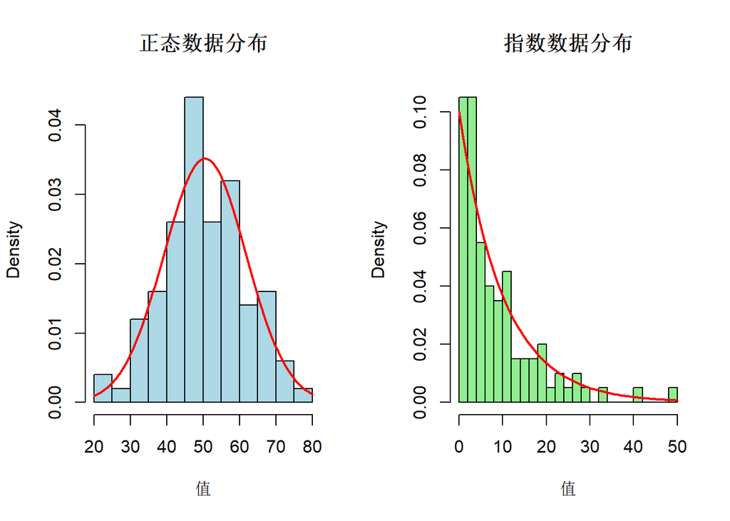

```r
# 可视化比较
par(mfrow = c(1, 2))

# 正态数据
hist(normal_data, breaks = 20, probability = TRUE,
     main = "正态数据分布", xlab = "值", col = "lightblue")
curve(dnorm(x, mean = mean(normal_data), sd = sd(normal_data)),
      add = TRUE, col = "red", lwd = 2)

# 指数数据
hist(exp_data, breaks = 20, probability = TRUE,
     main = "指数数据分布", xlab = "值", col = "lightgreen")
curve(dexp(x, rate = 0.1), add = TRUE, col = "red", lwd = 2)
```

```r
par(mfrow = c(1, 1))
```

### 6.1.2 卡方拟合优度检验

**数学基础**：

检验观测频数与期望频数是否一致。

**检验统计量**：
$$\chi^2 =
\sum\frac{(O_i - E_i)^2}{E_i}$$

```r
# 卡方拟合优度检验示例
# 场景：检验骰子是否公平

# 观测频数（掷骰子120次）
observed <- c(18, 22, 15, 20, 25, 20)
names(observed) <- 1:6

# 期望频数（公平骰子，每个面期望20次）
expected <- rep(20, 6)

# 卡方拟合优度检验
chisq_goodness <- chisq.test(observed, p = rep(1/6, 6))
chisq_goodness
```

```
##
##  Chi-squared test for given probabilities
##
## data:  observed
## X-squared = 2.9, df = 5, p-value = 0.7154
```

```r
# 查看期望频数
chisq_goodness$expected
```

```
##  1  2  3  4  5  6
## 20 20 20 20 20 20
```

```r
# 残差分析
chisq_goodness$residuals
```

```
##          1          2          3          4          5          6
## -0.4472136  0.4472136 -1.1180340  0.0000000  1.1180340  0.0000000
```

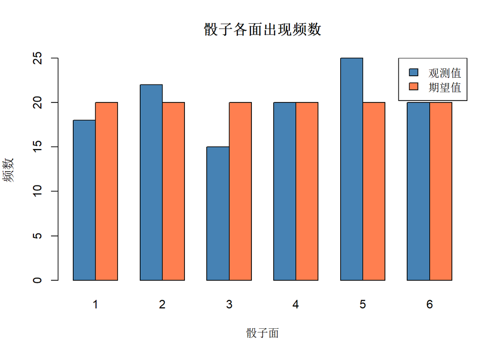

```r
# 可视化
barplot(rbind(observed, expected), beside = TRUE,
        names.arg = 1:6,
        main = "骰子各面出现频数",
        xlab = "骰子面", ylab = "频数",
        col = c("steelblue", "coral"))
legend("topright", legend = c("观测值", "期望值"),
       fill = c("steelblue", "coral"))
```

## 6.2 两独立样本非参数检验

### Mann-Whitney U检验（Wilcoxon秩和检验）

**数学基础**：

检验两个独立样本是否来自同一分布。

**检验统计量**：
$$U = n_1
n_2 + \frac{n_1(n_1+1)}{2} - R_1$$

其中$R_1$是第一组样本的秩和。

```r
# Mann-Whitney U检验示例
# 场景：比较两种药物的疗效评分（有序数据）

set.seed(99999)
drug_A <- sample(1:5, 30, replace = TRUE, prob = c(0.1, 0.15, 0.2, 0.3, 0.25))
drug_B <- sample(1:5, 30, replace = TRUE, prob = c(0.2, 0.25, 0.25, 0.2, 0.1))

# 创建数据框
score_data <- data.frame(
  score = c(drug_A, drug_B),
  drug = factor(rep(c("A", "B"), each = 30))
)

# 描述性统计
table(score_data$score, score_data$drug)
```

```
##
##      A  B
##   1  3  7
##   2  7  6
##   3  2  6
##   4  8  7
##   5 10  4
```

```r
# Wilcoxon秩和检验（Mann-Whitney U）
wilcox_test <- wilcox.test(score ~ drug, data = score_data)
wilcox_test
```

```
##
##  Wilcoxon rank sum test with continuity correction
##
## data:  score by drug
## W = 572.5, p-value = 0.0649
## alternative hypothesis: true location shift is not equal to 0
```

```r
# 使用coin包进行精确检验
coin_test <- coin::wilcox_test(score ~ drug, data = score_data,
                                distribution = "exact")
coin_test
```

```
##
##  Exact Wilcoxon-Mann-Whitney Test
##
## data:  score by drug (A, B)
## Z = 1.8535, p-value = 0.06261
## alternative hypothesis: true mu is not equal to 0
```

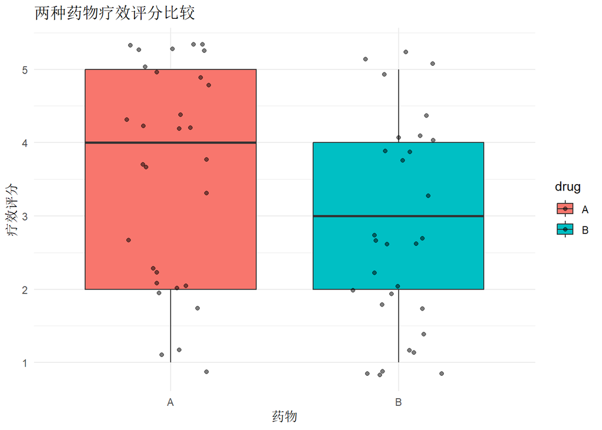

```r
# 可视化
ggplot2::ggplot(score_data, ggplot2::aes(x = drug, y = score, fill = drug)) +
  ggplot2::geom_boxplot() +
  ggplot2::geom_jitter(width = 0.2, alpha = 0.5) +
  ggplot2::labs(title = "两种药物疗效评分比较",
       x = "药物", y = "疗效评分") +
  ggplot2::theme_minimal()
```

## 6.3 两配对样本非参数检验

### Wilcoxon符号秩检验

**数学基础**：

检验配对差值的中位数是否为0。

```r
# Wilcoxon符号秩检验示例
set.seed(111111)
before <- rnorm(20, mean = 50, sd = 10)
after <- before + rnorm(20, mean = 3, sd = 5)

# Wilcoxon符号秩检验
wilcox_paired <- wilcox.test(before, after, paired = TRUE)
wilcox_paired
```

```
##
##  Wilcoxon signed rank exact test
##
## data:  before and after
## V = 48, p-value = 0.03277
## alternative hypothesis: true location shift is not equal to 0
```

```r
# 与配对t检验比较
t_paired <- t.test(before, after, paired = TRUE)

cat("Wilcoxon符号秩检验 p值:", wilcox_paired$p.value, "\n")
```

```
## Wilcoxon符号秩检验 p值: 0.03276825
```

```r
cat("配对t检验 p值:", t_paired$p.value, "\n")
```

```
## 配对t检验 p值: 0.06696449
```

```r
# 符号检验（更简单，但功效较低）
diff <- after - before
n_pos <- sum(diff > 0)
n_neg <- sum(diff < 0)
binom.test(n_pos, n_pos + n_neg, p = 0.5)
```

```
##
##  Exact binomial test
##
## data:  n_pos and n_pos + n_neg
## number of successes = 14, number of trials = 20, p-value = 0.1153
## alternative hypothesis: true probability of success is not equal to 0.5
## 95 percent confidence interval:
##  0.4572108 0.8810684
## sample estimates:
## probability of success
##                    0.7
```